# CACCS: Secuencia de taller de RStudio – Parte 3

#### 5.1.8.1 Estandarización de Variables

Para comparar los efectos de las variables en la misma escala, podemos estandarizar las variables numéricas:

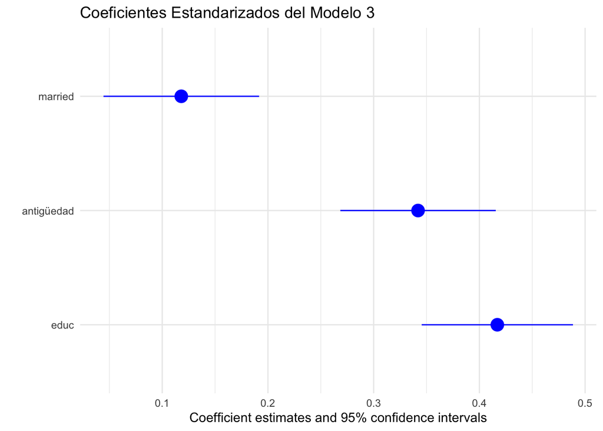

```r
base1_estandarizado <- base1 |>
  mutate(across(where(is.numeric), scale))

# Ajustamos el modelo con los datos estandarizados
mod3_est <- lm(wage ~ educ + antigüedad + married, data = base1_estandarizado)

# Visualicemos los coeficientes estandarizados
modelplot(mod3_est, coef_omit = "Intercept", color = "blue", size = 1) +
  labs(title = "Coeficientes Estandarizados del Modelo 3")
```

Los coeficientes estandarizados permiten comparar directamente el efecto relativo de cada variable en el salario. Un coeficiente más grande en valor absoluto indica un efecto mayor.

Al ejecutar `plot(mod3)`, obtenemos los gráficos diagnósticos para evaluar los supuestos del modelo.

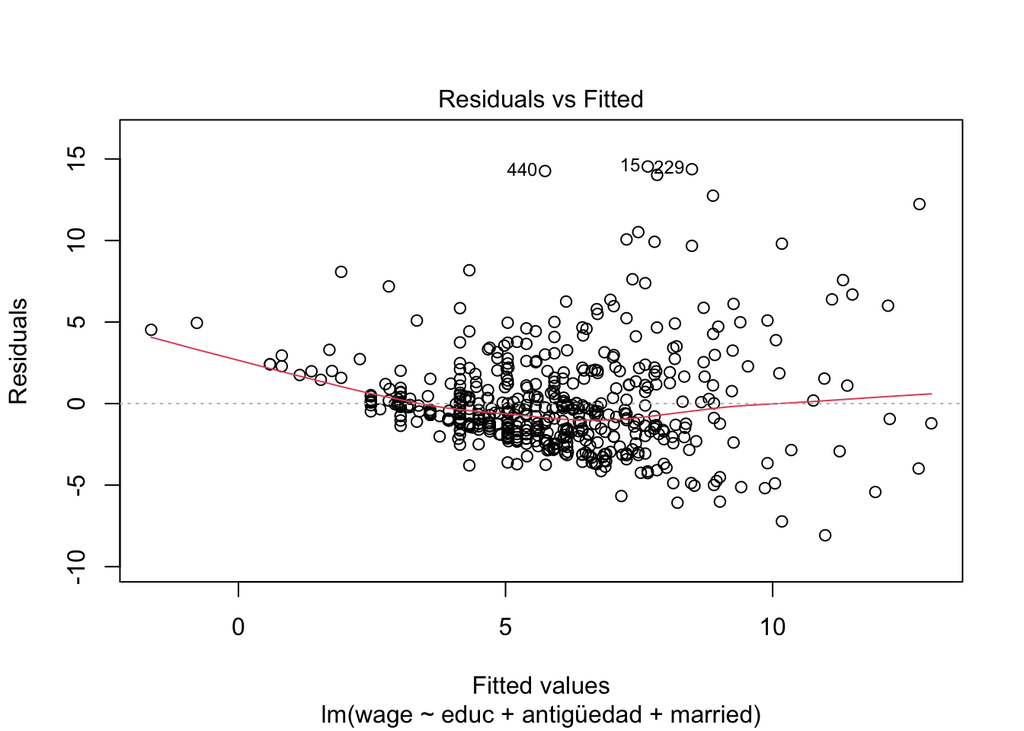

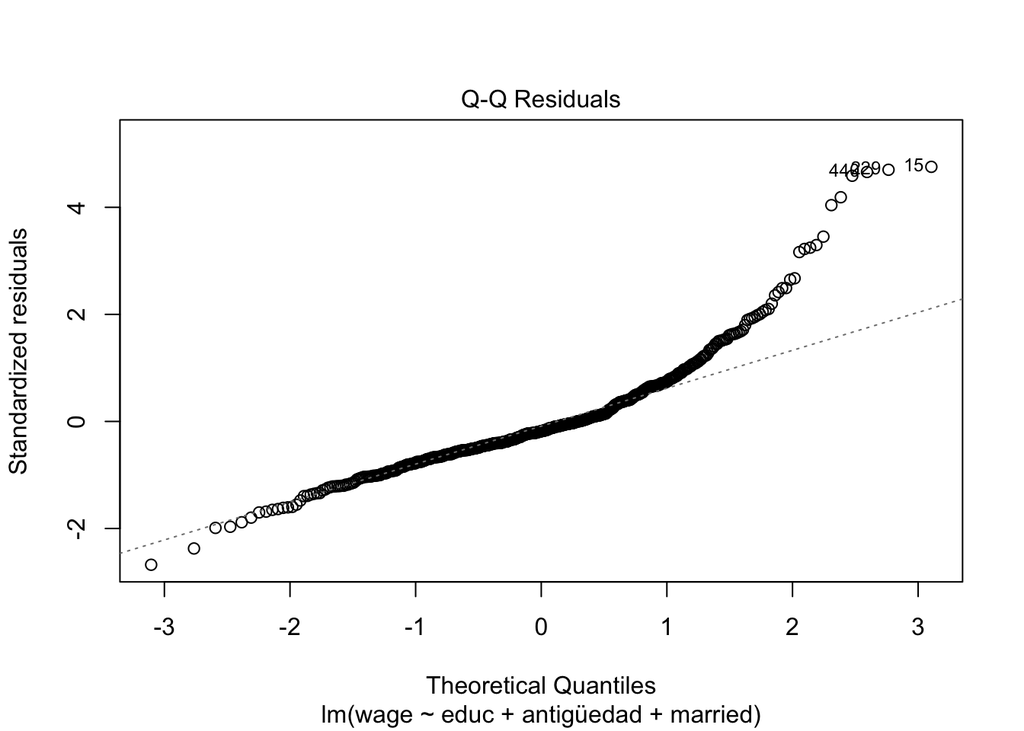

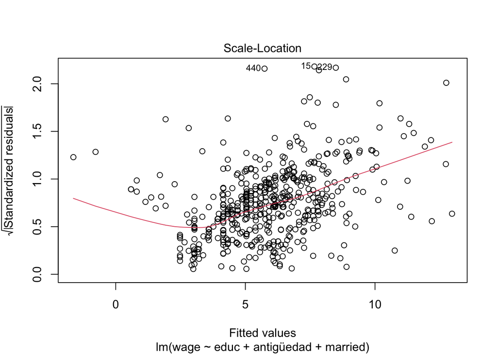

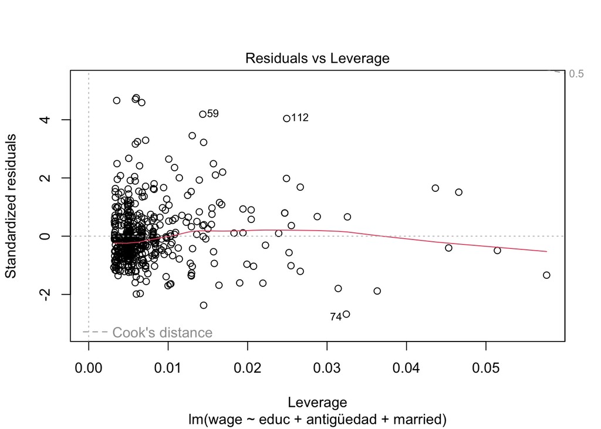

```r
plot(mod3)
```

```r
#library(lmtest)
bptest(mod3)
```

```
##
##  studentized Breusch-Pagan test
##
## data:  mod3
## BP = 43.296, df = 3, p-value = 2.129e-09
```

```r
shapiro.test(mod3$residuals)
```

```
##
##  Shapiro-Wilk normality test
##
## data:  mod3$residuals
## W = 0.89096, p-value < 2.2e-16
```

Los residuos todavía siguen distando de ser una distribución normal. Ampliaremos el modelo con otras variables que señaláramos antes como de interés.

```r
# Creamos un nuevo modelo incluyendo 'female' y 'nonwhite'
mod4 <- lm(wage ~ educ + antigüedad + married + female + nonwhite, data = base1)

# Resumen del modelo
summary(mod4)
```

```
##
## Call:
## lm(formula = wage ~ educ + antigüedad + married + female + nonwhite,
##     data = base1)
##
## Residuals:
##     Min      1Q  Median      3Q     Max
## -7.4948 -1.7690 -0.5398  1.0261 13.9814
##
## Coefficients:
##             Estimate Std. Error t value Pr(>|t|)
## (Intercept) -1.12270    0.66394  -1.691   0.0914 .
## educ         0.52878    0.04718  11.208  < 2e-16 ***
## antigüedad   0.15423    0.01873   8.234 1.47e-15 ***
## married      0.68258    0.27546   2.478   0.0135 *
## female      -1.71149    0.26644  -6.424 3.01e-10 ***
## nonwhite    -0.06516    0.42715  -0.153   0.8788
## ---
## Signif. codes:  0 '***' 0.001 '**' 0.01 '*' 0.05 '.' 0.1 ' ' 1
##
## Residual standard error: 2.956 on 520 degrees of freedom
## Multiple R-squared:  0.3653, Adjusted R-squared:  0.3592
## F-statistic: 59.85 on 5 and 520 DF,  p-value: < 2.2e-16
```

- Educación y antigüedad: Siguen siendo significativas y positivas.
- Married (0.68258): Estar casado se asocia con un aumento promedio de $0.68 en el salario, manteniendo constantes las demás variables.
- Female (-1.71149): Ser mujer se asocia con una disminución promedio de $1.71 en el salario, manteniendo constantes las demás variables. Este efecto es estadísticamente significativo.
- Nonwhite (-0.06516): No es estadísticamente significativo (p = 0.8788), lo que sugiere que, en este modelo, la variable nonwhite no tiene un efecto significativo en el salario.
- Ajuste del modelo:
  - R-cuadrado (0.3653), ajustado (0.3592): El modelo explica aproximadamente el 36% de la variabilidad en el salario, mejorando levemente respecto al modelo anterior.

#### 5.1.8.2 Análisis

Es importante verificar la multicolinealidad al añadir nuevas variables.

```r
#library(car)
vif(mod4)
```

```
##       educ antigüedad    married     female   nonwhite
##   1.025155   1.099796   1.087978   1.066217   1.011546
```

No parece haber problema de multicolinealidad, todas están cerca de 1.

Verificaremos rápido igual los gráficos del modelo.

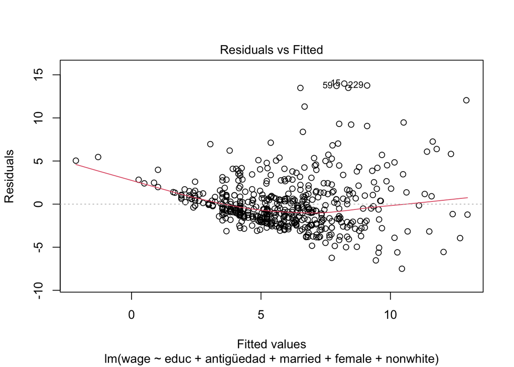

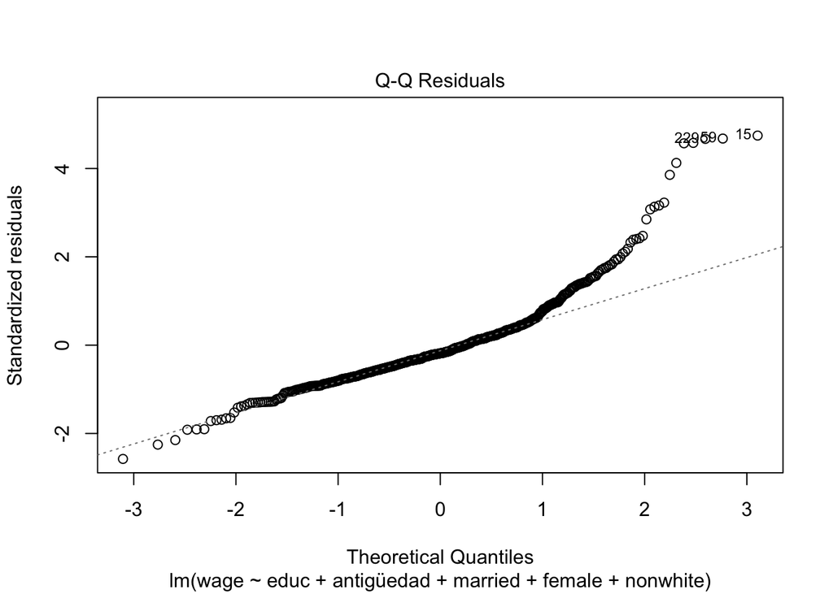

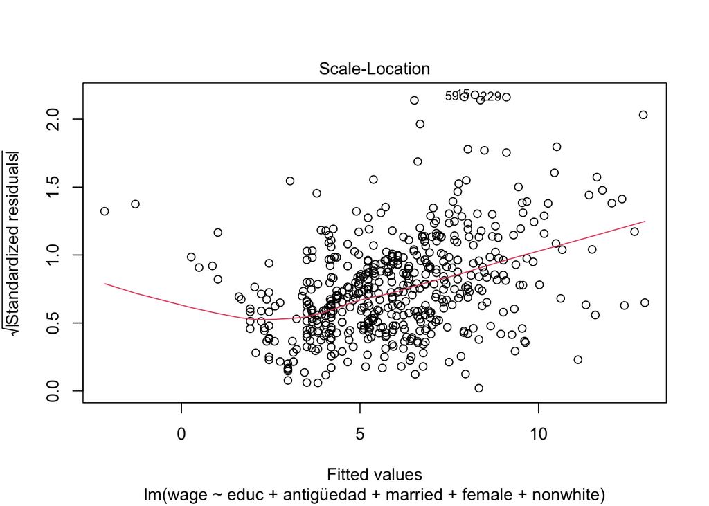

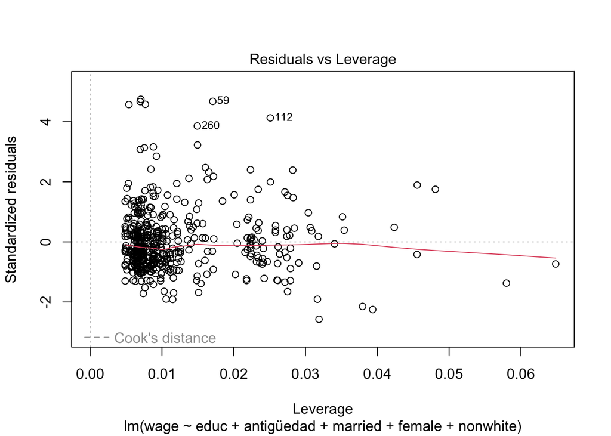

```r
plot(mod4)
```

```r
#library(lmtest)
bptest(mod4)
```

```
##
##  studentized Breusch-Pagan test
##
## data:  mod4
## BP = 43.589, df = 5, p-value = 2.806e-08
```

```r
shapiro.test(mod4$residuals)
```

```
##
##  Shapiro-Wilk normality test
##
## data:  mod4$residuals
## W = 0.88709, p-value < 2.2e-16
```

Seguimos rechazando la hipótesis nula de Shapiro-Wilk aún en este caso. El problema no parece ser resuelto por añadidura de otros términos. Aplicamos una transformación logarítmica a la variable dependiente, salario.

```r
# Estimamos el modelo con el logaritmo del salario
mod5 <- lm(log(wage) ~ educ + antigüedad + married + female + nonwhite, data = base1)

# Resumen del modelo
summary(mod5)
```

```
##
## Call:
## lm(formula = log(wage) ~ educ + antigüedad + married + female +
##     nonwhite, data = base1)
##
## Residuals:
##      Min       1Q   Median       3Q      Max
## -1.89855 -0.27105 -0.03577  0.24487  1.24663
##
## Coefficients:
##              Estimate Std. Error t value Pr(>|t|)
## (Intercept)  0.570835   0.092937   6.142 1.62e-09 ***
## educ         0.079483   0.006604  12.035  < 2e-16 ***
## antigüedad   0.019443   0.002622   7.416 4.94e-13 ***
## married      0.146703   0.038558   3.805 0.000159 ***
## female      -0.280401   0.037296  -7.518 2.45e-13 ***
## nonwhite    -0.002419   0.059791  -0.040 0.967738
## ---
## Signif. codes:  0 '***' 0.001 '**' 0.01 '*' 0.05 '.' 0.1 ' ' 1
##
## Residual standard error: 0.4138 on 520 degrees of freedom
## Multiple R-squared:  0.3996, Adjusted R-squared:  0.3939
## F-statistic: 69.23 on 5 and 520 DF,  p-value: < 2.2e-16
```

Interpretación:

Coeficientes interpretados en términos logarítmicos: - Educación (0.079483): Un año adicional de educación se asocia con un aumento promedio del 7.95% en el salario, manteniendo constantes las demás variables. - Antigüedad (0.019443): Un año adicional de antigüedad se asocia con un aumento promedio del 1.94% en el salario. - Married (0.146703): Estar casado se asocia con un aumento promedio del 14.67% en el salario. - Female (-0.280401): Ser mujer se asocia con una disminución promedio del 28.04% en el salario. - Nonwhite (-0.002419): No es significativo. - Mejora en los supuestos del modelo: - La transformación logarítmica puede ayudar a corregir problemas de heterocedasticidad y normalidad de los residuos.

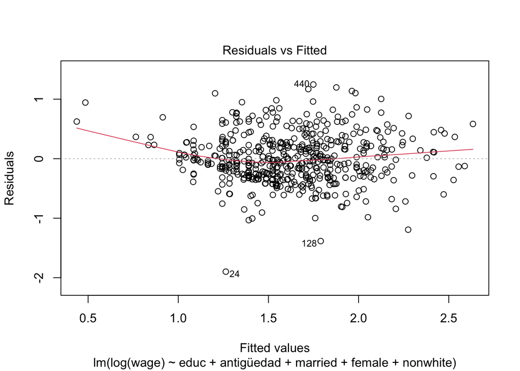

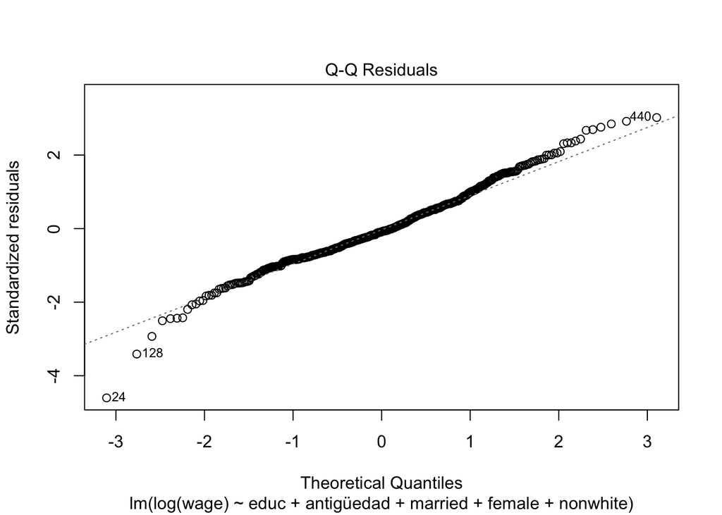

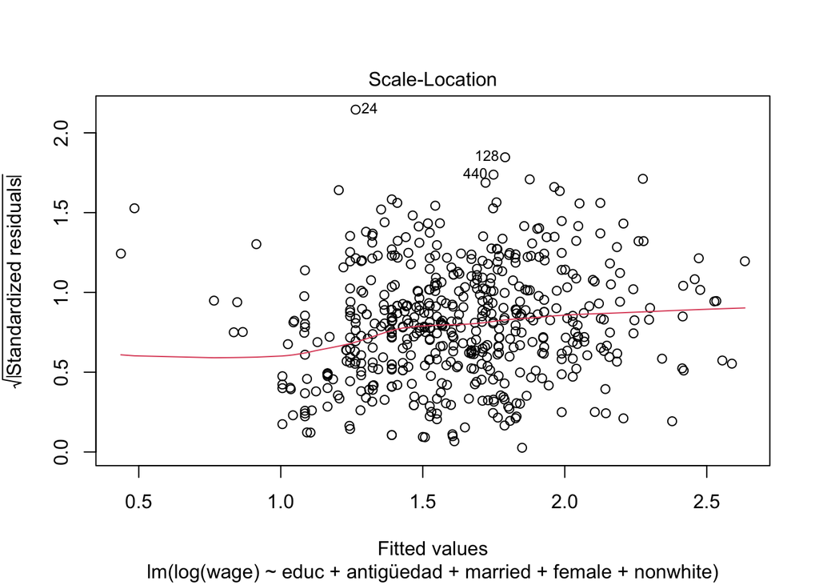

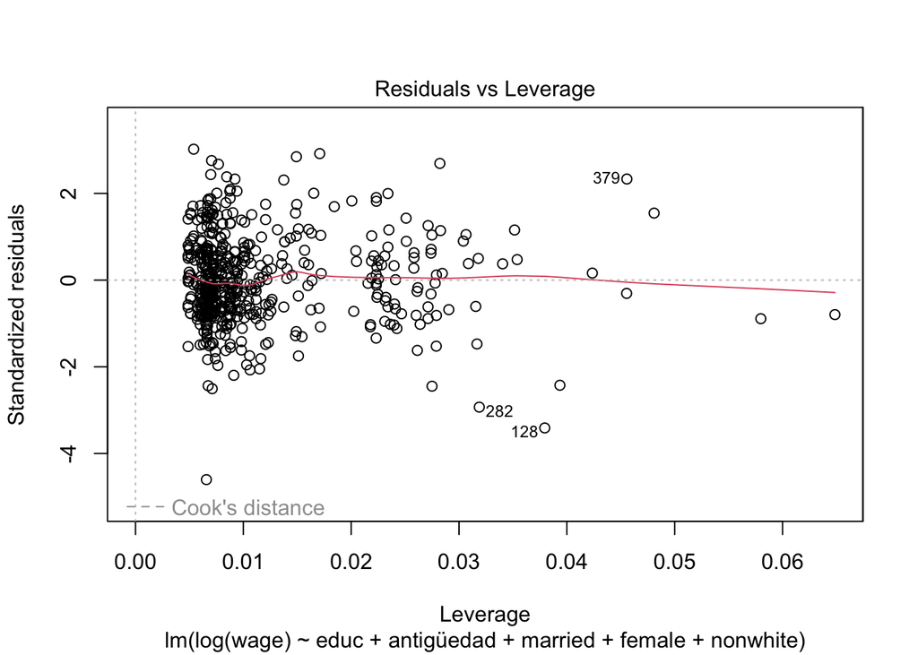

```r
plot(mod5)
```

Estos gráficos se ven **distintos** a los anteriores. Los residuos parecen dispersarse de manera más uniforme alrededor de cero. Hagamos varias pruebas para verificar:

```r
#library(lmtest)
bptest(mod5)
```

```
##
##  studentized Breusch-Pagan test
##
## data:  mod5
## BP = 11.928, df = 5, p-value = 0.03579
```

```r
shapiro.test(mod5$residuals)
```

```
##
##  Shapiro-Wilk normality test
##
## data:  mod5$residuals
## W = 0.98592, p-value = 5.75e-05
```

Sigue rechazándose la nula, aunque por menos margen que antes en el caso de Breusch-Pagan (y menos mejorado en Shapiro-Wilk).

Haremos unos últimos intentos de ajuste, como el uso de errores estándar robustos (ajustan las estimaciones de la varianza para corregir la heterocedasticidad sin cambiar los coeficientes estimados).

```r
# Instalar y cargar los paquetes necesarios
#install.packages("lmtest")
#install.packages("sandwich")
library(lmtest)
library(sandwich)

# Recalcular los errores estándar usando la matriz de varianza-covarianza robusta
coef(summary(mod5))
```

```
##                 Estimate  Std. Error     t value     Pr(>|t|)
## (Intercept)  0.570834892 0.092936693  6.14219071 1.618659e-09
## educ         0.079482847 0.006604044 12.03548155 1.330233e-29
## antigüedad   0.019442804 0.002621755  7.41594863 4.940979e-13
## married      0.146703436 0.038558103  3.80473683 1.588325e-04
## female      -0.280400745 0.037295927 -7.51826714 2.448824e-13
## nonwhite    -0.002419444 0.059791466 -0.04046471 9.677382e-01
```

```r
coeftest(mod5, vcov = vcovHC(mod5, type = "HC1"))
```

```
##
## t test of coefficients:
##
##               Estimate Std. Error t value  Pr(>|t|)
## (Intercept)  0.5708349  0.1019869  5.5971 3.531e-08 ***
## educ         0.0794828  0.0072800 10.9180 < 2.2e-16 ***
## antigüedad   0.0194428  0.0031956  6.0842 2.272e-09 ***
## married      0.1467034  0.0400634  3.6618 0.0002761 ***
## female      -0.2804007  0.0378265 -7.4128 5.048e-13 ***
## nonwhite    -0.0024194  0.0614213 -0.0394 0.9685938
## ---
## Signif. codes:  0 '***' 0.001 '**' 0.01 '*' 0.05 '.' 0.1 ' ' 1
```

Los coeficientes estimados permanecen iguales en este caso, pero los errores estándar y los valores p pueden cambiar. Para más información sobre este método recomiendo [este artículo](https://ideas.repec.org/p/ete/ceswps/ces0316.html).

Si quisiéramos hacer otras transformaciones adicionales, no satisfechos con estos errores robustos, podríamos buscar una transformación Box-Cox, un tipo de transformación de potencia que redistribuye la variable con un logaritmo y luego eleva a un exponente óptimo para normalizar la variable. Para más información recomiendo [este enlace](https://datasciencetut.com/box-cox-transformation-in-r/).

```r
# Instalar y cargar el paquete MASS
#install.packages("MASS")
library(MASS)
```

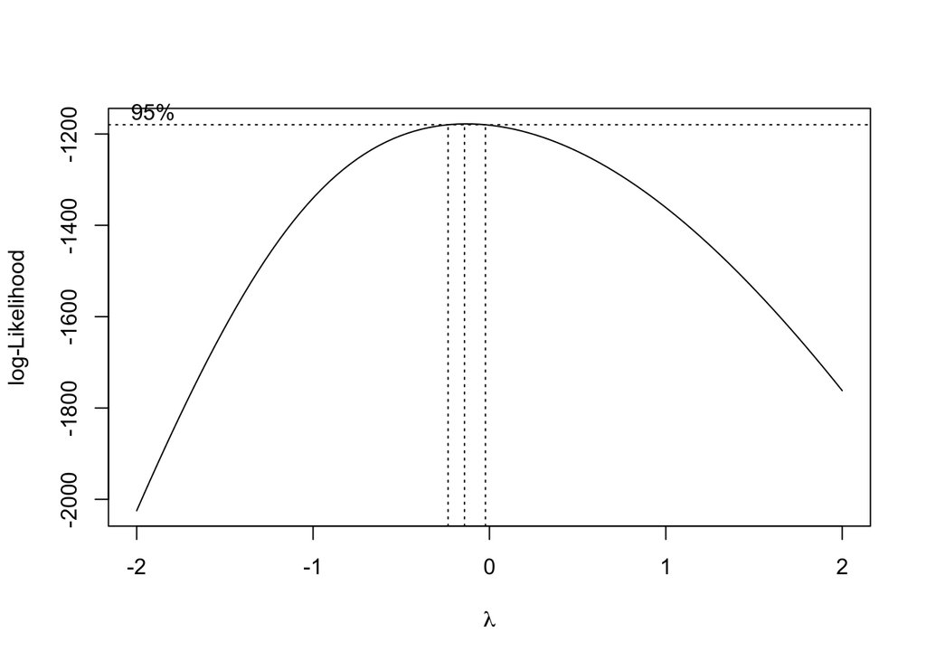

```r
# Encontrar el lambda óptimo para la transformación Box-Cox
boxcox_mod <- boxcox(mod4, plotit = TRUE)
```

```r
lambda_optimo <- boxcox_mod$x[which.max(boxcox_mod$y)]
lambda_optimo
```

```
## [1] -0.1414141
```

```r
# Aplicar la transformación Box-Cox al salario
base1$wage_boxcox <- (base1$wage^lambda_optimo - 1) / lambda_optimo

# Reestimar el modelo con la variable transformada
mod_boxcox <- lm(wage_boxcox ~ educ + antigüedad + married + female + nonwhite, data = base1)
summary(mod_boxcox)
```

```
##
## Call:
## lm(formula = wage_boxcox ~ educ + antigüedad + married + female +
##     nonwhite, data = base1)
##
## Residuals:
##      Min       1Q   Median       3Q      Max
## -1.81512 -0.21056 -0.02169  0.20059  0.90536
##
## Coefficients:
##              Estimate Std. Error t value Pr(>|t|)
## (Intercept)  0.612834   0.073483   8.340 6.71e-16 ***
## educ         0.062016   0.005222  11.877  < 2e-16 ***
## antigüedad   0.014772   0.002073   7.126 3.47e-12 ***
## married      0.120575   0.030487   3.955 8.72e-05 ***
## female      -0.220928   0.029489  -7.492 2.94e-13 ***
## nonwhite    -0.001225   0.047276  -0.026    0.979
## ---
## Signif. codes:  0 '***' 0.001 '**' 0.01 '*' 0.05 '.' 0.1 ' ' 1
##
## Residual standard error: 0.3272 on 520 degrees of freedom
## Multiple R-squared:  0.3941, Adjusted R-squared:  0.3883
## F-statistic: 67.64 on 5 and 520 DF,  p-value: < 2.2e-16
```

```r
# Verificar los supuestos nuevamente
shapiro.test(mod_boxcox$residuals)
```

```
##
##  Shapiro-Wilk normality test
##
## data:  mod_boxcox$residuals
## W = 0.98056, p-value = 1.786e-06
```

```r
bptest(mod_boxcox)
```

```
##
##  studentized Breusch-Pagan test
##
## data:  mod_boxcox
## BP = 8.7255, df = 5, p-value = 0.1205
```

No rechazamos la hipótesis nula de homocedasticidad por Breusch-Pagan. La heterocedasticidad se ha mitigado en este modelo. Sin embargo, rechazamos la hipótesis nula de normalidad. Los residuos aún no siguen una distribución normal.

También podríamos incluir otros términos polinomiales o interacciones.

```r
# Modelo con términos cuadráticos
mod_poly <- lm(log(wage) ~ educ + I(educ^2) + antigüedad + I(antigüedad^2) + married + female + nonwhite, data = base1)

# Resumen del modelo
summary(mod_poly)
```

```
##
## Call:
## lm(formula = log(wage) ~ educ + I(educ^2) + antigüedad + I(antigüedad^2) +
##     married + female + nonwhite, data = base1)
##
## Residuals:
##      Min       1Q   Median       3Q      Max
## -1.86343 -0.25631 -0.02747  0.24719  1.26424
##
## Coefficients:
##                   Estimate Std. Error t value Pr(>|t|)
## (Intercept)      1.0890157  0.1836224   5.931 5.52e-09 ***
## educ            -0.0200558  0.0298881  -0.671 0.502501
## I(educ^2)        0.0042157  0.0012474   3.380 0.000780 ***
## antigüedad       0.0407787  0.0064974   6.276 7.34e-10 ***
## I(antigüedad^2) -0.0008442  0.0002312  -3.652 0.000287 ***
## married          0.1264775  0.0381141   3.318 0.000969 ***
## female          -0.2668000  0.0367257  -7.265 1.38e-12 ***
## nonwhite        -0.0262610  0.0586796  -0.448 0.654678
## ---
## Signif. codes:  0 '***' 0.001 '**' 0.01 '*' 0.05 '.' 0.1 ' ' 1
##
## Residual standard error: 0.4048 on 518 degrees of freedom
## Multiple R-squared:  0.4277, Adjusted R-squared:   0.42
## F-statistic: 55.31 on 7 and 518 DF,  p-value: < 2.2e-16
```

```r
# Verificar los supuestos
shapiro.test(mod_poly$residuals)
```

```
##
##  Shapiro-Wilk normality test
##
## data:  mod_poly$residuals
## W = 0.98657, p-value = 9.058e-05
```

```r
bptest(mod_poly)
```

```
##
##  studentized Breusch-Pagan test
##
## data:  mod_poly
## BP = 11.462, df = 7, p-value = 0.1197
```

Tampoco rechazamos en esta transformación la hipótesis nula de homoscedasticidad. La heteroscedasticidad se ha reducido. Pero sí volvemos a notar que los errores no son normales. Soluciones como bootstrapping podrían ser útiles, así como modelos generalizados. Por ahora, podemos enfocarnos en sacar las tablas de los modelos, para uso en o para otros programas.

```r
library(stargazer)
stargazer(mod1,mod2,mod3,mod4,mod5,mod_boxcox) #de base, para LaTeX
```

```
##
## % Table created by stargazer v.5.2.3 by Marek Hlavac, Social Policy Institute. E-mail: marek.hlavac at gmail.com
## % Date and time: Fri, Feb 21, 2025 - 11:19:28
## \begin{table}[!htbp] \centering
##   \caption{}
##   \label{}
## \begin{tabular}{@{\extracolsep{5pt}}lcccccc}
## \\[-1.8ex]\hline
## \hline \\[-1.8ex]
##  & \multicolumn{6}{c}{\textit{Dependent variable:}} \\
## \cline{2-7}
## \\[-1.8ex] & \multicolumn{4}{c}{wage} & log(wage) & wage\_boxcox \\
## \\[-1.8ex] & (1) & (2) & (3) & (4) & (5) & (6)\\
## \hline \\[-1.8ex]
##  educ & 0.541$^{***}$ & 0.569$^{***}$ & 0.556$^{***}$ & 0.529$^{***}$ & 0.079$^{***}$ & 0.062$^{***}$ \\
##   & (0.053) & (0.049) & (0.049) & (0.047) & (0.007) & (0.005) \\
##   & & & & & & \\
##  antigüedad &  & 0.190$^{***}$ & 0.175$^{***}$ & 0.154$^{***}$ & 0.019$^{***}$ & 0.015$^{***}$ \\
##   &  & (0.019) & (0.019) & (0.019) & (0.003) & (0.002) \\
##   & & & & & & \\
##  married &  &  & 0.892$^{***}$ & 0.683$^{**}$ & 0.147$^{***}$ & 0.121$^{***}$ \\
##   &  &  & (0.283) & (0.275) & (0.039) & (0.030) \\
##   & & & & & & \\
##  female &  &  &  & $-$1.711$^{***}$ & $-$0.280$^{***}$ & $-$0.221$^{***}$ \\
##   &  &  &  & (0.266) & (0.037) & (0.029) \\
##   & & & & & & \\
##  nonwhite &  &  &  & $-$0.065 & $-$0.002 & $-$0.001 \\
##   &  &  &  & (0.427) & (0.060) & (0.047) \\
##   & & & & & & \\
##  Constant & $-$0.905 & $-$2.222$^{***}$ & $-$2.526$^{***}$ & $-$1.123$^{*}$ & 0.571$^{***}$ & 0.613$^{***}$ \\
##   & (0.685) & (0.640) & (0.642) & (0.664) & (0.093) & (0.073) \\
##   & & & & & & \\
## \hline \\[-1.8ex]
## Observations & 526 & 526 & 526 & 526 & 526 & 526 \\
## R$^{2}$ & 0.165 & 0.302 & 0.315 & 0.365 & 0.400 & 0.394 \\
## Adjusted R$^{2}$ & 0.163 & 0.299 & 0.311 & 0.359 & 0.394 & 0.388 \\
## Residual Std. Error & 3.378 (df = 524) & 3.092 (df = 523) & 3.066 (df = 522) & 2.956 (df = 520) & 0.414 (df = 520) & 0.327 (df = 520) \\
## F Statistic & 103.363$^{***}$ (df = 1; 524) & 113.067$^{***}$ (df = 2; 523) & 79.978$^{***}$ (df = 3; 522) & 59.848$^{***}$ (df = 5; 520) & 69.227$^{***}$ (df = 5; 520) & 67.641$^{***}$ (df = 5; 520) \\
## \hline
## \hline \\[-1.8ex]
## \textit{Note:}  & \multicolumn{6}{r}{$^{*}$p$<$0.1; $^{**}$p$<$0.05; $^{***}$p$<$0.01} \\
## \end{tabular}
## \end{table}
```

```r
stargazer(mod1,mod2,mod3, type="text", title = "Resultados de regresión")
```

```
##
## Resultados de regresión
## =============================================================================================
##                                                Dependent variable:
##                     -------------------------------------------------------------------------
##                                                       wage
##                               (1)                      (2)                      (3)
## ---------------------------------------------------------------------------------------------
## educ                        0.541***                 0.569***                0.556***
##                             (0.053)                  (0.049)                  (0.049)
##
## antigüedad                                           0.190***                0.175***
##                                                      (0.019)                  (0.019)
##
## married                                                                      0.892***
##                                                                               (0.283)
##
## Constant                     -0.905                 -2.222***                -2.526***
##                             (0.685)                  (0.640)                  (0.642)
##
## ---------------------------------------------------------------------------------------------
## Observations                  526                      526                      526
## R2                           0.165                    0.302                    0.315
## Adjusted R2                  0.163                    0.299                    0.311
## Residual Std. Error     3.378 (df = 524)         3.092 (df = 523)        3.066 (df = 522)
## F Statistic         103.363*** (df = 1; 524) 113.067*** (df = 2; 523) 79.978*** (df = 3; 522)
## =============================================================================================
## Note:                                                             *p<0.1; **p<0.05; ***p<0.01
```

```r
stargazer(mod4,mod5,mod_boxcox, type="text", title = "Resultados de regresión 2")#de base, para LaTeX
```

```
##
## Resultados de regresión 2
## ==============================================================
##                                      Dependent variable:
##                                -------------------------------
##                                  wage    log(wage) wage_boxcox
##                                   (1)       (2)        (3)
## --------------------------------------------------------------
## educ                           0.529***  0.079***   0.062***
##                                 (0.047)   (0.007)    (0.005)
##
## antigüedad                     0.154***  0.019***   0.015***
##                                 (0.019)   (0.003)    (0.002)
##
## married                         0.683**  0.147***   0.121***
##                                 (0.275)   (0.039)    (0.030)
##
## female                         -1.711*** -0.280***  -0.221***
##                                 (0.266)   (0.037)    (0.029)
##
## nonwhite                        -0.065    -0.002     -0.001
##                                 (0.427)   (0.060)    (0.047)
##
## Constant                        -1.123*  0.571***   0.613***
##                                 (0.664)   (0.093)    (0.073)
##
## --------------------------------------------------------------
## Observations                      526       526        526
## R2                               0.365     0.400      0.394
## Adjusted R2                      0.359     0.394      0.388
## Residual Std. Error (df = 520)   2.956     0.414      0.327
## F Statistic (df = 5; 520)      59.848*** 69.227***  67.641***
## ==============================================================
## Note:                              *p<0.1; **p<0.05; ***p<0.01
```

# 6 Modelos lineales generalizados

Al trabajar con datos como los de salarios en el conjunto de datos de Wooldridge, podemos encontrar problemas con las suposiciones fundamentales de los Mínimos Cuadrados Ordinarios (OLS). Aunque los modelos lineales clásicos nos proporcionan resultados, estos pueden ser problemáticos si los errores no están bien distribuidos, es decir, si violan los supuestos de normalidad y homocedasticidad. Esto significa que las inferencias obtenidas pueden no ser adecuadas o estar sesgadas.

Para abordar estas limitaciones, los Modelos Lineales Generalizados (GLM) extienden el marco de los modelos lineales al permitir una mayor flexibilidad en la relación entre las variables independientes y la variable dependiente. Un GLM se compone de tres elementos clave:

1. Predictor lineal ($\eta$): $\eta=𝑋𝛽$

Donde *X* es la matriz de variables independientes y **𝛽** es el vector de coeficientes.

2. Función de Enlace ($𝑔$): Esta es monótona y diferenciable en todo su dominio, y que transforma el predictor lineal $g(\mu) = \eta$. Su inversa permite obtener las predicciones de la variable dependiente: $𝑦̂ = 𝑔⁻¹(𝑋𝛽̂)$, $\hat{y} = g^{-1}(\eta)$).
3. Distribución de Respuesta: La variable dependiente se asume que sigue una distribución de la familia exponencial, denotada por $f(y | \mu)$ . Algunas distribuciones comunes incluyen la normal, binomial, Poisson y gamma.

Estos componentes proporcionan la flexibilidad necesaria para modelar diferentes tipos de variables dependientes, permitiendo que el modelo capture mejor las características de los datos y aborde problemas como la heterocedasticidad y la no normalidad de los errores, así como cuando el rango de la variable de respuesta está limitado, entre otros.

En R, la función glm() se utiliza para ajustar Modelos Lineales Generalizados. Esta función permite especificar tanto la distribución de la variable dependiente como la función de enlace adecuada.

**Sintaxis básica de glm()**

```r
glm(formula, family = family_type(link = link_function), data = dataset)
```

- `formula`: Especifica la relación entre las variables dependiente e independientes (similar a `lm()`).
- `family`: Define la distribución de la variable dependiente. Puede ser `gaussian` (para regresión lineal), `binomial` (para regresión logística), `poisson` (para modelos de conteo), `gamma`, entre otros.
- `link`: Es la función de enlace que conecta la media de la variable dependiente con las variables independientes (por ejemplo, `log`, `identity` o `inverse`).

La función de enlace predeterminada para una familia puede cambiarse especificando un enlace a la función de familia. Si no se informa nada, el modelo correrá en la práctica un modelo lineal simple. Comparen los resultados:

```r
glm(wage ~ educ + antigüedad + married, data = base1)
```

```
##
## Call:  glm(formula = wage ~ educ + antigüedad + married, data = base1)
##
## Coefficients:
## (Intercept)         educ   antigüedad      married
##     -2.5258       0.5561       0.1748       0.8924
##
## Degrees of Freedom: 525 Total (i.e. Null);  522 Residual
## Null Deviance:       7160
## Residual Deviance: 4906  AIC: 2677
```

```r
lm(wage ~ educ + antigüedad + married, data = base1)
```

```
##
## Call:
## lm(formula = wage ~ educ + antigüedad + married, data = base1)
##
## Coefficients:
## (Intercept)         educ   antigüedad      married
##     -2.5258       0.5561       0.1748       0.8924
```

Por ejemplo, si la variable de respuesta es no negativa y la varianza es proporcional a la media, se usaría la función de enlace “identity” con la familia “quasipoisson”. Esto se especificaría como:

```r
family = quasipoisson(link = "identity")
```

La decisión sobre qué familia es apropiada no se discute a profundidad en esta secuencia, pero estos pueden ser:

```r
binomial(link = "logit")
gaussian(link = "identity")
Gamma(link = "inverse")
inverse.gaussian(link = "1/mu^2")
poisson(link = "log")
quasi(link = "identity", variance = "constant")
quasibinomial(link = "logit")
quasipoisson(link = "log")
```

- gaussian: Para variables continuas que siguen una distribución normal (equivalente a la regresión lineal clásica).
- binomial: Para variables categóricas binarias (regresión logística).
- poisson: Para datos de conteo (números enteros no negativos).
- Gamma: Para variables continuas y positivas, especialmente cuando la varianza aumenta con la media.
- inverse.gaussian: Para variables continuas positivas con varianza que aumenta rápidamente con la media.

Algunas funciones de enlace comunes son: - identity: Sin transformación (usada en regresión lineal). - log: Transforma la media mediante el logaritmo natural (útil para variables positivas). - logit: Función logística, usada en regresión logística. - inverse: Utiliza la inversa de la media.

Cada familia tiene una función de enlace predeterminada, pero puede modificarse según las necesidades del análisis. Revisar la página de ayuda de `glm` y la documentacion de objetos familiares para modelos ayudará en gran medida.

Volviendo al ejemplo que traíamos antes, queremos modelar el salario (wage), que es una variable continua y positiva, y sospechamos que la varianza aumenta con la media. Podemos utilizar la familia Gamma con una función de enlace logarítmica, a través de `family = Gamma(link = "log")`:

```r
# Ajustando un modelo GLM con distribución gamma y enlace logarítmico
mod_glm <- glm(wage ~ educ + antigüedad + married + female + nonwhite,
                 family = Gamma(link = "log"), data = base1)

# Resumen del modelo
summary(mod_glm)
```

```
##
## Call:
## glm(formula = wage ~ educ + antigüedad + married + female +
##     nonwhite, family = Gamma(link = "log"), data = base1)
##
## Coefficients:
##               Estimate Std. Error t value Pr(>|t|)
## (Intercept)  0.6336436  0.1007043   6.292 6.65e-10 ***
## educ         0.0817722  0.0071560  11.427  < 2e-16 ***
## antigüedad   0.0217897  0.0028409   7.670 8.53e-14 ***
## married      0.1220276  0.0417808   2.921  0.00364 **
## female      -0.2856600  0.0404131  -7.068 5.07e-12 ***
## nonwhite    -0.0003761  0.0647888  -0.006  0.99537
## ---
## Signif. codes:  0 '***' 0.001 '**' 0.01 '*' 0.05 '.' 0.1 ' ' 1
##
## (Dispersion parameter for Gamma family taken to be 0.2010781)
##
##     Null deviance: 158.876  on 525  degrees of freedom
## Residual deviance:  90.711  on 520  degrees of freedom
## AIC: 2305
##
## Number of Fisher Scoring iterations: 6
```

Los coeficientes representan el efecto multiplicativo de las variables independientes sobre el salario. Por pasos:

El intercepto se interpreta como el valor cuando las variables independientes son cero. En este caso, el logaritmo del salario esperado es 0.6336. - Exponenciando el intercepto: $exp(0.6336) ≈ 1.884$. - Esto significa que, para una persona con cero años de educación y antigüedad, no casada, hombre y blanco, el salario promedio esperado es aproximadamente $1.88 por hora (recordemos, esto es de 1976).

Cada año adicional de educación se asocia con un incremento en el logaritmo del salario de 0.08177. Los coeficientes se han de exponenciar (y son multiplicativos, entendiéndose como cambios porcentuales por unidad adicional).

```r
exp(coef(mod_glm))
```

```
## (Intercept)        educ  antigüedad     married      female    nonwhite
##   1.8844643   1.0852086   1.0220288   1.1297853   0.7515181   0.9996239
```

Por ejemplo, por cada año adicional de educación, el salario promedio aumenta en aproximadamente un 8.53%, manteniendo constantes las demás variables. En el caso de la variable ‘dummy’, como female, el exponenciado es menos que uno. Esto implica que las mujeres ganaban, en promedio, un 24.82% menos que los hombres, manteniendo constantes las demás variables en el modelo. Otros elementos en las columnas del estimado son similares a lo que vimos al usar `lm()`.

Sin embargo tenemos información adicional. Hay un parámetro de dispersión. Este es un estimado de la varianza de los residuos en el modelo Gamma. Un valor más pequeño indica menor variabilidad de los datos alrededor del modelo ajustado. La raíz cuadrada de ese parámetro es la desviación estándar estimada. Las desviaciones nulas y residuales son comparaciones entre un modelo vacío (con sólo un intercepto), y el modelo ajustado con todas las variables.

En este caso reporta el criterio de información de Akaike, que es una medida de la calidad del modelo que penaliza por la complejidad (número de parámetros). Al comparar modelos, un AIC más bajo indica un modelo preferido. Como sólo tenemos un modelo, el AIC nos sirve para comparar con futuros modelos alternativos. Finalmente, declara la cantidad de Iteraciones que fueron necesarias para converger y encontrar los estimadores de máxima verosimilitud.

Verifiquemos otra vez con el modelo transformado

```r
# Resumen del modelo
summary(mod5)
```

```
##
## Call:
## lm(formula = log(wage) ~ educ + antigüedad + married + female +
##     nonwhite, data = base1)
##
## Residuals:
##      Min       1Q   Median       3Q      Max
## -1.89855 -0.27105 -0.03577  0.24487  1.24663
##
## Coefficients:
##              Estimate Std. Error t value Pr(>|t|)
## (Intercept)  0.570835   0.092937   6.142 1.62e-09 ***
## educ         0.079483   0.006604  12.035  < 2e-16 ***
## antigüedad   0.019443   0.002622   7.416 4.94e-13 ***
## married      0.146703   0.038558   3.805 0.000159 ***
## female      -0.280401   0.037296  -7.518 2.45e-13 ***
## nonwhite    -0.002419   0.059791  -0.040 0.967738
## ---
## Signif. codes:  0 '***' 0.001 '**' 0.01 '*' 0.05 '.' 0.1 ' ' 1
##
## Residual standard error: 0.4138 on 520 degrees of freedom
## Multiple R-squared:  0.3996, Adjusted R-squared:  0.3939
## F-statistic: 69.23 on 5 and 520 DF,  p-value: < 2.2e-16
```

Notamos que la transformación aproxima los coeficientes a los conseguidos con el `glm()`.

```r
library(arm)
```

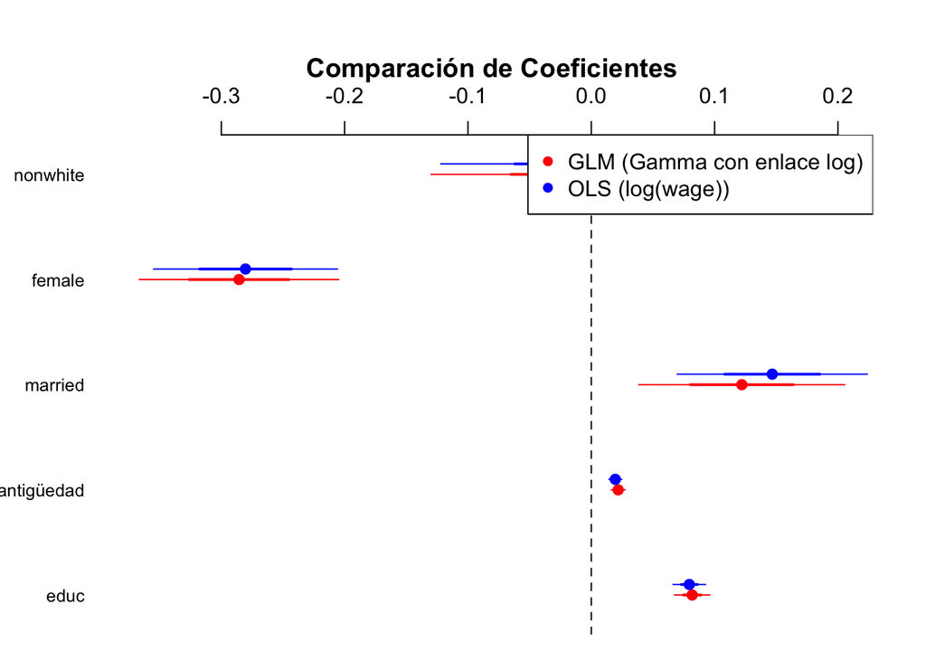

```r
# Gráfico de coeficientes para el modelo GLM
coefplot(mod_glm, col.pts = "red", cex.pts = 1.5, main = "Comparación de Coeficientes")

# Añadimos los coeficientes del modelo OLS al mismo gráfico
coefplot(mod5, add = TRUE, col.pts = "blue", cex.pts = 1.5)

legend("topright", legend = c("GLM (Gamma con enlace log)", "OLS (log(wage))"),
       col = c("red", "blue"), pch = 16)
```

## 6.1 Análisis de la bondad del modelo

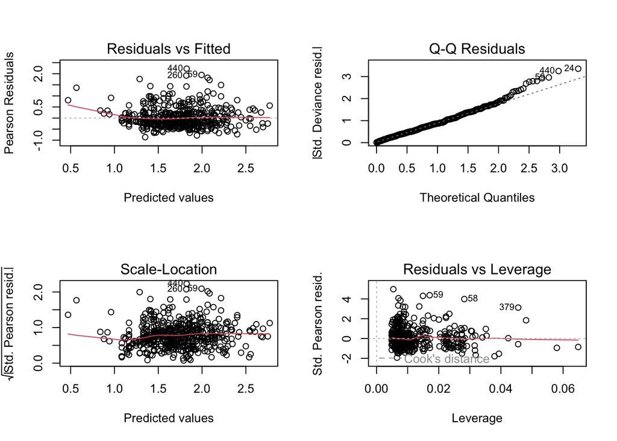

```r
# Generamos los gráficos diagnósticos
par(mfrow = c(2, 2))
plot(mod_glm)
```

Esto se ve posiblemente mejor que la variante de OLS, aunque tampoco parece perfecto.

# 7 Modelos jerárquicos

Los modelos jerárquicos, también conocidos como modelos lineales mixtos o modelos multinivel, son una extensión de los modelos lineales que permiten analizar datos en los que las observaciones están agrupadas o anidadas en diferentes niveles. Estos modelos son especialmente útiles cuando se espera que exista correlación entre las observaciones dentro de los mismos grupos.

En este análisis, utilizaremos el paquete `lme4` en R, que es ampliamente utilizado para ajustar modelos lineales mixtos. A continuación, te guiaré a través de los pasos para ajustar y comprender estos modelos, explicando cada componente y resultado de manera clara. La sintaxis de `lme4` se basa en la sintaxis de los modelos lineales que ya conocemos de `lm()`.

La función `lmer()` de `lme4` añade la especificación de la variable de grupo/sujeto y de la estructura de efectos aleatorios que se van a estimar. En paréntesis adicionales (ver abajo), el término a la izquierda de `|` especifica los efectos aleatorios que se van a estimar. El término a la derecha de `|` representa la(s) variable(s) que definen la estructura de agrupación (o anidamiento) de los datos.

Un `1` en la parte izquierda del paréntesis significa que se debe estimar un componente de varianza de intercepto aleatorio. Si también se coloca la variable predictora a la izquierda de `|`, esto indica que se deben incluir pendientes aleatorias. La forma básica de estos será:

```r
lmer(data = datos, VarDependiente ~ VarIndependiente + (1 | VarGrupal))
```

Corresponde a un modelo que puede describirse de la siguiente manera: “La variable dependiente es predicha por la variable independiente. Al mismo tiempo, la varianza de los residuos de nivel 2 del intercepto es un parámetro del modelo”.

Comencemos con modelos HLM que incluyen solo variables predictoras de nivel 1 (individuos anidados en grupos). Luego, en un segundo paso, añadiremos predictores de nivel 2. Finalmente, analizaremos los modelos HLM de medidas repetidas, donde el nivel más bajo (nivel 1) corresponde a observaciones repetidas dentro de los individuos, y esas observaciones están anidadas en los participantes individuales (nivel 2).

Nos limitaremos aquí a modelos de 2 niveles. Los principios de los modelos HLM pueden ilustrarse de manera bastante parsimoniosa de esta forma, y expandir los modelos a más de dos niveles de análisis es bastante sencillo.

```r
# Cargar las librerías necesarias
#library(tidyverse)
library(lme4)
library(lmerTest)
# Cargar los datos desde una URL
df <- read_csv("https://raw.githubusercontent.com/methodenlehre/data/master/salary-data.csv")
# Convertir las variables 'firma' y 'sector' en factores
df <- df |>
  mutate(firma = as.factor(firma),
         sector = as.factor(sector))

# Ver las últimas filas del conjunto de datos
tail(df)
```

```
## # A tibble: 6 × 4
##   firma    experience salary sector
##   <fct>         <dbl>  <dbl> <fct>
## 1 Firma 20       3.58  6838. Privat
## 2 Firma 20       3.18  7604. Privat
## 3 Firma 20       3.39  5714. Privat
## 4 Firma 20       7.12 10089. Privat
## 5 Firma 20       2.98  6940. Privat
## 6 Firma 20       6.45  9330. Privat
```

## 7.1 Modelo nulo

En este caso saco unos datos de salarios de compañías ficticias en Suiza. Con `mutate()` convertí las variables firma (empresa) y sector en factores, ya que representan categorías. Antes de añadir predictores, ajustamos un modelo nulo que solo incluye el intercepto y un término aleatorio para capturar la variabilidad entre las empresas (firma). Este modelo nos permite estimar la correlación intraclase (ICC) y entender qué proporción de la variabilidad total del salario se debe a diferencias entre empresas.

```r
library(Matrix)
library(lme4)
# Ajustar el modelo nulo con intercepto aleatorio por empresa
modelo_nulo <- lmer(salary ~ 1 + (1 | firma), data = df, REML = TRUE)

# Obtener las predicciones del modelo nulo
df$predicciones_nulo <- predict(modelo_nulo)

# Resumen del modelo
summary(modelo_nulo)
```

```
## Linear mixed model fit by REML. t-tests use Satterthwaite's method [
## lmerModLmerTest]
## Formula: salary ~ 1 + (1 | firma)
##    Data: df
##
## REML criterion at convergence: 10433.5
##
## Scaled residuals:
##     Min      1Q  Median      3Q     Max
## -2.9816 -0.6506 -0.0494  0.5779  4.2131
##
## Random effects:
##  Groups   Name        Variance Std.Dev.
##  firma    (Intercept)  851249   922.6
##  Residual             1954745  1398.1
## Number of obs: 600, groups:  firma, 20
##
## Fixed effects:
##             Estimate Std. Error     df t value Pr(>|t|)
## (Intercept)   8737.6      214.1   19.0   40.82   <2e-16 ***
## ---
## Signif. codes:  0 '***' 0.001 '**' 0.01 '*' 0.05 '.' 0.1 ' ' 1
```

Explicación:

- lmer(): Ajusta un modelo lineal mixto.
- `salary ~ 1`: Indica que solo se ajusta el intercepto fijo (media general del salario).
- `(1 | firma)`: Especifica un intercepto aleatorio para cada empresa (firma), capturando la variabilidad entre empresas.
- `REML = TRUE`: Utiliza el método de Máxima Verosimilitud Restringida para estimar los parámetros, lo cual es apropiado cuando se comparan modelos con diferentes efectos fijos.
- `predict()`: Genera predicciones del modelo para cada observación.

La varianza del intercepto aleatorio (firma) representa la variabilidad del salario promedio entre empresas. Por otro lado la varianza residual captura la variabilidad del salario dentro de las empresas. Calcularemos la correlación intraclase como la proporción de la varianza total que se debe a diferencias entre empresas. Se define como: $\rho = \frac{\sigma^2_{\text{Nivel-2}}}{\sigma^2_{\text{Nivel-2}} + \sigma^2_{\text{Nivel-1}}}$

```r
# Extraer las varianzas del modelo
var_intercepto <- as.numeric(VarCorr(modelo_nulo)$firma[1])
var_residual <- attr(VarCorr(modelo_nulo), "sc")^2

# Calcular la ICC
ICC <- var_intercepto / (var_intercepto + var_residual)
ICC
```

```
## [1] 0.303368
```

Correlación intraclase: $\hat{\rho} = \frac{\hat{\sigma}^2_{υ_0}}{\hat{\sigma}^2_{υ_0} + \hat{\sigma}^2_{ϵ}} = \frac{851249}{851249 + 1954745} = 0.3034$

Es decir, 30% de la variabilidad total del salario se debe a diferencias entre empresas. Existe una correlación notable entre los salarios de los empleados dentro de la misma empresa, lo que justifica el uso de un modelo multinivel.

Con la función ranef() podemos ver los efectos aleatorios (residuos de segundo nivel del intercepto):

```r
ranef(modelo_nulo)
```

```
## $firma
##          (Intercept)
## Firma 01   789.65416
## Firma 02  1105.01807
## Firma 03  1923.02618
## Firma 04 -1136.50080
## Firma 05   953.54595
## Firma 06  -958.93185
## Firma 07   -10.14627
## Firma 08  -254.84048
## Firma 09  -651.31802
## Firma 10   768.48590
## Firma 11  -506.26620
## Firma 12   940.40709
## Firma 13  -742.84383
## Firma 14  -975.45482
## Firma 15 -1161.36931
## Firma 16   -97.68008
## Firma 17   661.96052
## Firma 18  -168.11195
## Firma 19   351.23926
## Firma 20  -829.87351
##
## with conditional variances for "firma"
```

Para determinar si la varianza entre empresas es estadísticamente significativa, comparamos el modelo nulo con un modelo sin efectos aleatorios (modelo lineal simple).

```r
# Utilizar la función ranova() para comparar modelos
anova_aleatorio <- ranova(modelo_nulo)
anova_aleatorio
```

```
## ANOVA-like table for random-effects: Single term deletions
##
## Model:
## salary ~ (1 | firma)
##             npar  logLik   AIC    LRT Df Pr(>Chisq)
## <none>         3 -5216.7 10440
## (1 | firma)    2 -5295.5 10595 157.44  1  < 2.2e-16 ***
## ---
## Signif. codes:  0 '***' 0.001 '**' 0.01 '*' 0.05 '.' 0.1 ' ' 1
```

Este comparó el modelo actual con un modelo reducido que elimina el efecto aleatorio. El valor p indica que incluir el intercepto aleatorio para firma mejora significativamente el modelo. Aproximadamente, el 30% de la varianza total del salario se puede atribuir a diferencias entre empresas.

## 7.2 Modelo con predictor de primer nivel

Ahora, añadimos un predictor de nivel 1 (experience), que es una variable individual, al modelo. Mantenemos el intercepto aleatorio para capturar la variabilidad entre empresas.

```r
# Ajustar el modelo con 'experience' como predictor fijo y intercepto aleatorio por empresa
modelo_intercepto_aleatorio <- lmer(salary ~ experience + (1 | firma), data = df, REML = TRUE)

# Obtener las predicciones del modelo
df$predicciones_intercepto_aleatorio <- predict(modelo_intercepto_aleatorio)

# Resumen del modelo
summary(modelo_intercepto_aleatorio)
```

```
## Linear mixed model fit by REML. t-tests use Satterthwaite's method [
## lmerModLmerTest]
## Formula: salary ~ experience + (1 | firma)
##    Data: df
##
## REML criterion at convergence: 10127.1
##
## Scaled residuals:
##     Min      1Q  Median      3Q     Max
## -2.8109 -0.6884  0.0005  0.5980  3.8833
##
## Random effects:
##  Groups   Name        Variance Std.Dev.
##  firma    (Intercept)  614367   783.8
##  Residual             1184502  1088.3
## Number of obs: 600, groups:  firma, 20
##
## Fixed effects:
##             Estimate Std. Error      df t value Pr(>|t|)
## (Intercept)  5964.18     229.41   48.00   26.00   <2e-16 ***
## experience    534.34      27.21  589.48   19.64   <2e-16 ***
## ---
## Signif. codes:  0 '***' 0.001 '**' 0.01 '*' 0.05 '.' 0.1 ' ' 1
##
## Correlation of Fixed Effects:
##            (Intr)
## experience -0.615
```

Los resultados del modelo mixto muestran que el efecto fijo de la experiencia es significativamente positivo, con un coeficiente estimado de $\hat{\gamma}_{10} = 534.34$ y un valor $p$ menor a 0.001. Esto indica que, en promedio, el salario aumenta en aproximadamente 534 unidades (por ejemplo, francos suizos) por cada año adicional de experiencia, controlando por las diferencias entre empresas. El modelo incluye un intercepto aleatorio a nivel de empresa (firma), lo que nos permite ajustar diferencias entre las empresas en los salarios base.

Se le puede añadir un nivel adicional al modelo para tanto acomodar por un intercepto así como pendiente aleatoria. Al aplicar este modelo la varianza (aleatoria) de la pendiente de la variable independiente de primer nivel se puede estimar, dándonos una idea de las diferencias en el efecto (pendiente) de experiencia en salario entre las unidades del segundo nivel (firmas). Si comparamos los efectos entre este y el modelo anterior, vemos la disminución marginal de la varianza del intercepto aleatorio en comparación con el modelo nulo, lo que sugiere que parte de la variabilidad entre empresas se explica por la experiencia de los empleados.

```r
fixef(modelo_intercepto_aleatorio)
```

```
## (Intercept)  experience
##   5964.1757    534.3446
```

```r
ranef(modelo_intercepto_aleatorio)
```

```
## $firma
##          (Intercept)
## Firma 01   204.30371
## Firma 02   646.14732
## Firma 03  1492.00151
## Firma 04  -910.78990
## Firma 05   389.16512
## Firma 06  -924.63977
## Firma 07   577.66959
## Firma 08  -516.51767
## Firma 09  -638.24646
## Firma 10   768.48113
## Firma 11  -619.55111
## Firma 12  1091.33530
## Firma 13  -773.67207
## Firma 14  -738.17926
## Firma 15  -652.94087
## Firma 16    57.33923
## Firma 17   458.05487
## Firma 18   -89.38416
## Firma 19   944.22822
## Firma 20  -764.80474
##
## with conditional variances for "firma"
```

## 7.3 Modelo con pendientes aleatorias

Para investigar si el efecto de la experiencia en el salario varía entre empresas, ajustamos un modelo que incluye tanto intercepto como pendiente aleatorios para experience.

```r
# Ajustar el modelo con intercepto y pendiente aleatorios por empresa
modelo_coeficientes_aleatorios <- lmer(salary ~ experience + (experience | firma), data = df, REML = TRUE)

# Obtener las predicciones del modelo
df$predicciones_coeficientes_aleatorios <- predict(modelo_coeficientes_aleatorios)

# Resumen del modelo
summary(modelo_coeficientes_aleatorios)
```

```
## Linear mixed model fit by REML. t-tests use Satterthwaite's method [
## lmerModLmerTest]
## Formula: salary ~ experience + (experience | firma)
##    Data: df
##
## REML criterion at convergence: 10117.1
##
## Scaled residuals:
##     Min      1Q  Median      3Q     Max
## -2.8307 -0.6804  0.0037  0.5999  3.3608
##
## Random effects:
##  Groups   Name        Variance Std.Dev. Corr
##  firma    (Intercept)  722588   850.1
##           experience    18392   135.6   -0.51
##  Residual             1136296  1066.0
## Number of obs: 600, groups:  firma, 20
##
## Fixed effects:
##             Estimate Std. Error      df t value Pr(>|t|)
## (Intercept)  5933.72     240.38   18.89   24.68 7.77e-16 ***
## experience    530.85      40.59   18.95   13.08 6.20e-11 ***
## ---
## Signif. codes:  0 '***' 0.001 '**' 0.01 '*' 0.05 '.' 0.1 ' ' 1
##
## Correlation of Fixed Effects:
##            (Intr)
## experience -0.690
```

En este caso `(experience | firma)` especifica que tanto el intercepto como la pendiente de experience varían aleatoriamente entre empresas.

Los resultados muestran que el efecto fijo de la experiencia sigue siendo significativamente positivo, con un coeficiente estimado de $\hat{\gamma}_{10} = 530.85$ y un valor $p$ menor a 0.001. Esto indica que, en promedio, el salario aumenta en aproximadamente 531 unidades (por ejemplo, CHF para estos datos ficticios) por cada año adicional de experiencia. Una covarianza negativa sugiere que las empresas con salarios base más altos tienden a tener incrementos más pequeños por año de experiencia, y viceversa.

Para evaluar si el modelo con pendientes aleatorias proporciona un mejor ajuste que el modelo con solo intercepto aleatorio, realizamos una comparación de modelos.

```r
# Ajustar el modelo con intercepto aleatorio (modelo reducido)
modelo_intercepto_aleatorio <- lmer(salary ~ experience + (1 | firma), data = df, REML = FALSE)

# Ajustar el modelo con intercepto y pendiente aleatorios (modelo completo)
modelo_coeficientes_aleatorios <- lmer(salary ~ experience + (experience | firma), data = df, REML = FALSE)

# Comparar los modelos utilizando ANOVA
anova(modelo_intercepto_aleatorio, modelo_coeficientes_aleatorios)
```

```
## Data: df
## Models:
## modelo_intercepto_aleatorio: salary ~ experience + (1 | firma)
## modelo_coeficientes_aleatorios: salary ~ experience + (experience | firma)
##                                npar   AIC   BIC  logLik deviance  Chisq Df
## modelo_intercepto_aleatorio       4 10156 10173 -5073.9    10148
## modelo_coeficientes_aleatorios    6 10150 10177 -5069.2    10138 9.3127  2
##                                Pr(>Chisq)
## modelo_intercepto_aleatorio
## modelo_coeficientes_aleatorios   0.009501 **
## ---
## Signif. codes:  0 '***' 0.001 '**' 0.01 '*' 0.05 '.' 0.1 ' ' 1
```

El p-valor pequeño indica que el modelo con pendientes aleatorias es significativamente mejor que el modelo con solo intercepto aleatorio. Existe variación significativa en el efecto de la experiencia en el salario entre empresas.

Para ayudar a comprender mejor los resultados, es útil visualizar cómo varía el efecto de la experiencia en el salario entre empresas.

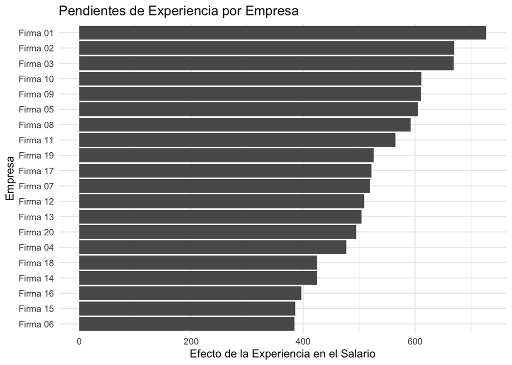

```r
#library(ggplot2)
# Extraer los coeficientes aleatorios
coeficientes_aleatorios <- coef(modelo_coeficientes_aleatorios)$firma

# Renombrar las columnas
colnames(coeficientes_aleatorios) <- c("Intercepto", "Pendiente")

# Añadir el identificador de la empresa
coeficientes_aleatorios$firma <- rownames(coeficientes_aleatorios)

# Graficar las pendientes de experiencia por empresa
ggplot(coeficientes_aleatorios, aes(x = reorder(firma, Pendiente), y = Pendiente)) +
  geom_bar(stat = "identity") +
  coord_flip() +
  labs(title = "Pendientes de Experiencia por Empresa",
       x = "Empresa",
       y = "Efecto de la Experiencia en el Salario") +
  theme_minimal()
```

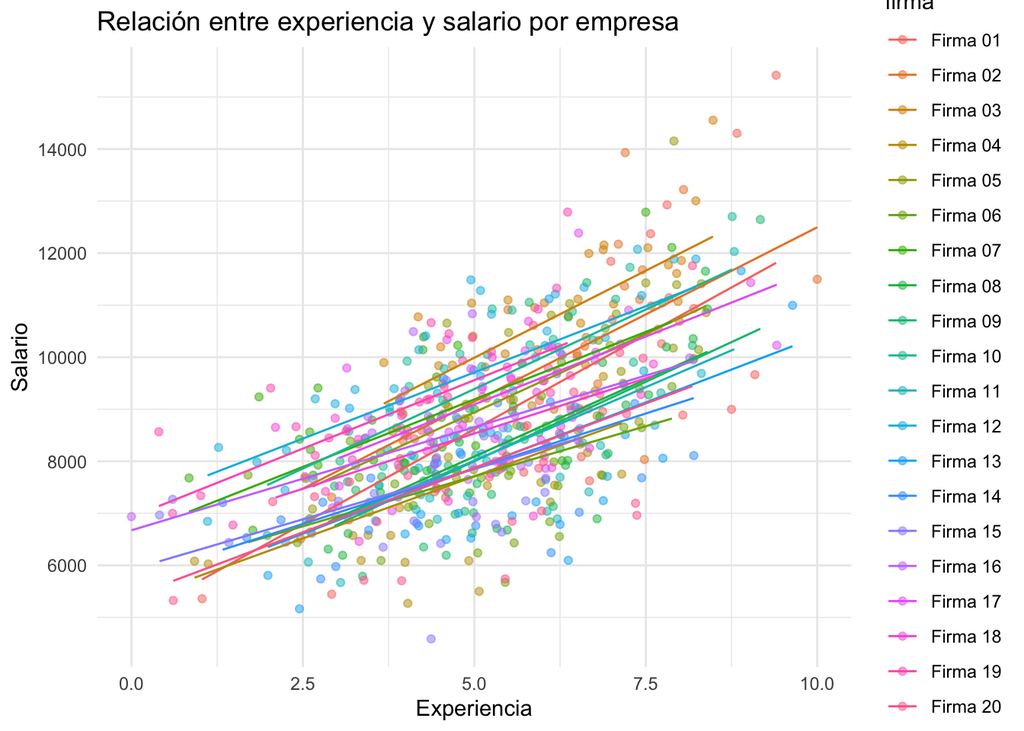

```r
# Crear un conjunto de datos con las predicciones del modelo
df$predicciones <- predict(modelo_coeficientes_aleatorios)

# Graficar los datos y las líneas de regresión por empresa
ggplot(df, aes(x = experience, y = salary, color = firma, group = firma)) +
  geom_point(alpha = 0.5) +
  geom_line(aes(y = predicciones)) +
  labs(title = "Relación entre experiencia y salario por empresa",
       x = "Experiencia",
       y = "Salario") +
  theme_minimal()
```

# 8 Modelos longitudinales

Los modelos longitudinales son una herramienta estadística esencial para analizar datos en los que se realizan observaciones repetidas de los mismos individuos a lo largo del tiempo. Este tipo de análisis es fundamental en campos como la medicina, psicología, economía, política, sociología y otras disciplinas donde es importante entender cómo cambian las mediciones en los individuos o unidades a lo largo del tiempo y qué factores influyen en esos cambios.

Los datos longitudinales son un caso especial de datos jerárquicos o multinivel, donde las observaciones (mediciones) están anidadas dentro de individuos. En este contexto, las observaciones repetidas de un mismo individuo tienden a ser más similares entre sí que las observaciones de diferentes individuos. Esta correlación dentro de los sujetos es crucial y debe ser tenida en cuenta para obtener inferencias estadísticas válidas. Una vista general sobre paquetes útiles en R para analizar este tipo de datos correlacionados se puede encontrar en la [CRAN Task View dedicada](https://cran.r-project.org/web/views/MixedModels.html).

En este taller, exploraremos cómo ajustar y analizar modelos longitudinales utilizando R, centrándonos en un conjunto de datos que mide el crecimiento dental en niños y niñas a diferentes edades. Trabajaremos con un conjunto de datos que contiene medidas longitudinales del crecimiento dental en 27 niños (16 niños y 11 niñas). Las medidas corresponden a la distancia pituitaria-pterigomaxilar (una medida de crecimiento dental) y se tomaron a las edades de 8, 10, 12 y 14 años. Nuestro objetivo es describir cómo cambia esta distancia con la edad y comparar el patrón de crecimiento entre niños y niñas.

Primero, cargamos los datos y observamos su estructura:

```r
load(url("http://alecri.github.io/downloads/data/dental.RData"))
head(dental)
```

```
## # A tibble: 6 × 6
##      id sex      y8   y10   y12   y14
##   <dbl> <fct> <dbl> <dbl> <dbl> <dbl>
## 1     1 Girl   21    20    21.5  23
## 2     2 Girl   21    21.5  24    25.5
## 3     3 Girl   20.5  24    24.5  26
## 4     4 Girl   23.5  24.5  25    26.5
## 5     5 Girl   21.5  23    22.5  23.5
## 6     6 Girl   20    21    21    22.5
```

Los datos se presentan en formato ancho, donde las mediciones repetidas se encuentran en columnas separadas para cada edad. Este formato no es ideal para el análisis longitudinal, por lo que convertiremos los datos a un formato largo usando la función pivot_longer():

```r
library(labelled)   # etiquetado de datos
library(rstatix)    # estadísticas descriptivas
library(ggpubr)     # estadísticas descriptivas y gráficos convenientes
library(GGally)     # gráficos avanzados
library(car)        # útil para ANOVA/pruebas de Wald
library(Epi)        # fácil obtención de intervalos de confianza para coeficientes/predicciones del modelo
#library(lme4)       # modelos lineales de efectos mixtos
#library(lmerTest)   # pruebas para modelos lineales de efectos mixtos
library(emmeans)    # medias marginales
library(multcomp)   # intervalos de confianza para combinaciones lineales de coeficientes del modelo
library(geepack)    # ecuaciones de estimación generalizadas
library(ggeffects)  # efectos marginales, predicciones ajustadas
library(gt)         # tablas bonitas
dental_long <- pivot_longer(dental, cols = starts_with("y"),
                            names_to = "measurement", values_to = "distance") |>
  mutate(
    age = parse_number(measurement),
    measurement = fct_inorder(paste("Medida a los", age))
  ) |>
  set_variable_labels(
    age = "Edad del niño/a al momento de la medición",
    measurement = "Etiqueta de medición temporal",
    distance = "Medición de distancia"
  )

head(dental_long)
```

```
## # A tibble: 6 × 5
##      id sex   measurement     distance   age
##   <dbl> <fct> <fct>              <dbl> <dbl>
## 1     1 Girl  Medida a los 8      21       8
## 2     1 Girl  Medida a los 10     20      10
## 3     1 Girl  Medida a los 12     21.5    12
## 4     1 Girl  Medida a los 14     23      14
## 5     2 Girl  Medida a los 8      21       8
## 6     2 Girl  Medida a los 10     21.5    10
```

Ahora, cada fila representa una medición de un individuo en una edad específica, lo que facilita el análisis longitudinal. Antes de ajustar modelos, exploramos los datos de forma descriptiva para entender las tendencias generales.

```r
group_by(dental_long, age) |>
  get_summary_stats(distance)
```

```
## # A tibble: 4 × 14
##     age variable     n   min   max median    q1    q3   iqr   mad  mean    sd
##   <dbl> <fct>    <dbl> <dbl> <dbl>  <dbl> <dbl> <dbl> <dbl> <dbl> <dbl> <dbl>
## 1     8 distance    27  16.5  27.5     22  21    23.2  2.25  1.48  22.2  2.43
## 2    10 distance    27  19    28       23  21.5  24.5  3     2.22  23.2  2.16
## 3    12 distance    27  19    31       24  23    26    3     2.22  24.6  2.82
## 4    14 distance    27  19.5  31.5     26  25    27.8  2.75  2.22  26.1  2.77
## # ℹ 2 more variables: se <dbl>, ci <dbl>
```

Observamos que la distancia media aumenta con la edad, lo que sugiere un crecimiento dental a medida que los niños y niñas crecen. Creamos un diagrama de caja para visualizar la distribución de la distancia a cada edad:

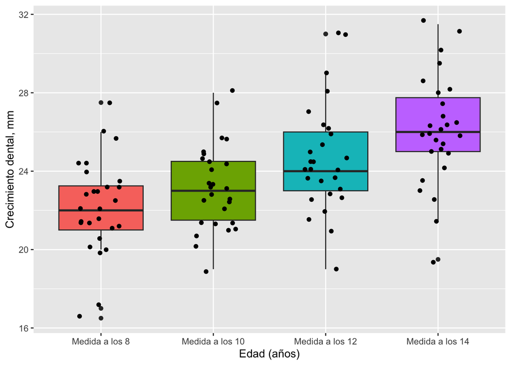

```r
ggplot(dental_long, aes(measurement, distance, fill = measurement)) +
  geom_boxplot() +
  geom_jitter(width = 0.2) +
  guides(fill = "none") +
  labs(x = "Edad (años)", y = "Crecimiento dental, mm")
```

El gráfico muestra que la mediana y los valores de la distancia aumentan con la edad. La dispersión también parece aumentar ligeramente, lo que indica mayor variabilidad en edades superiores. Exploremos si hay diferencias en el crecimiento dental entre niños y niñas.

```r
group_by(dental_long, sex, measurement) |>
  get_summary_stats(distance, show = c("mean", "sd"))
```

```
## # A tibble: 8 × 6
##   sex   measurement     variable     n  mean    sd
##   <fct> <fct>           <fct>    <dbl> <dbl> <dbl>
## 1 Girl  Medida a los 8  distance    11  21.2  2.12
## 2 Girl  Medida a los 10 distance    11  22.2  1.90
## 3 Girl  Medida a los 12 distance    11  23.1  2.37
## 4 Girl  Medida a los 14 distance    11  24.1  2.44
## 5 Boy   Medida a los 8  distance    16  22.9  2.45
## 6 Boy   Medida a los 10 distance    16  23.8  2.14
## 7 Boy   Medida a los 12 distance    16  25.7  2.65
## 8 Boy   Medida a los 14 distance    16  27.5  2.08
```

Y gráficamente

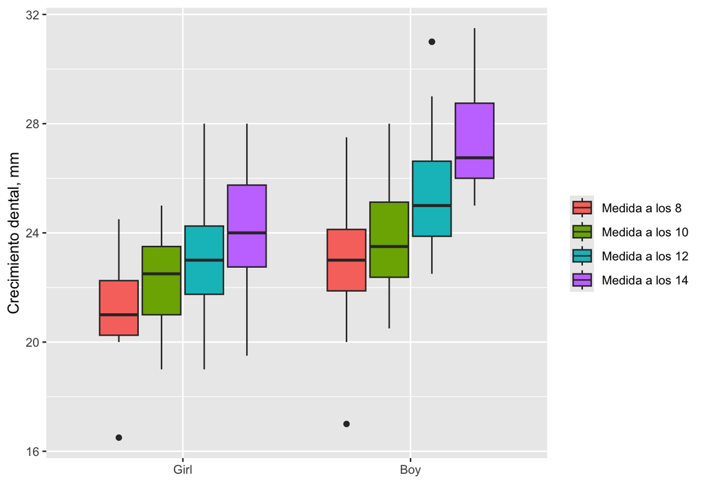

```r
ggplot(dental_long, aes(sex, distance, fill = measurement)) +
  geom_boxplot() +
  labs(x = "", y = "Crecimiento dental, mm", fill = "")
```

Visualmente, parece que los niños tienen, en promedio, una distancia ligeramente mayor que las niñas en cada edad.

Evaluemos las correlaciones entre medidas de interés:

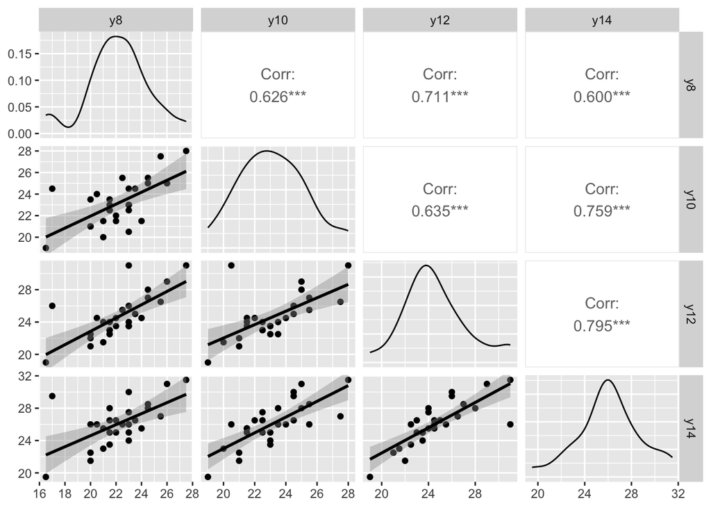

```r
ggpairs(select(dental, starts_with("y")), lower = list(continuous = "smooth"))
```

y separemos nuevamente por grupo (sexo)

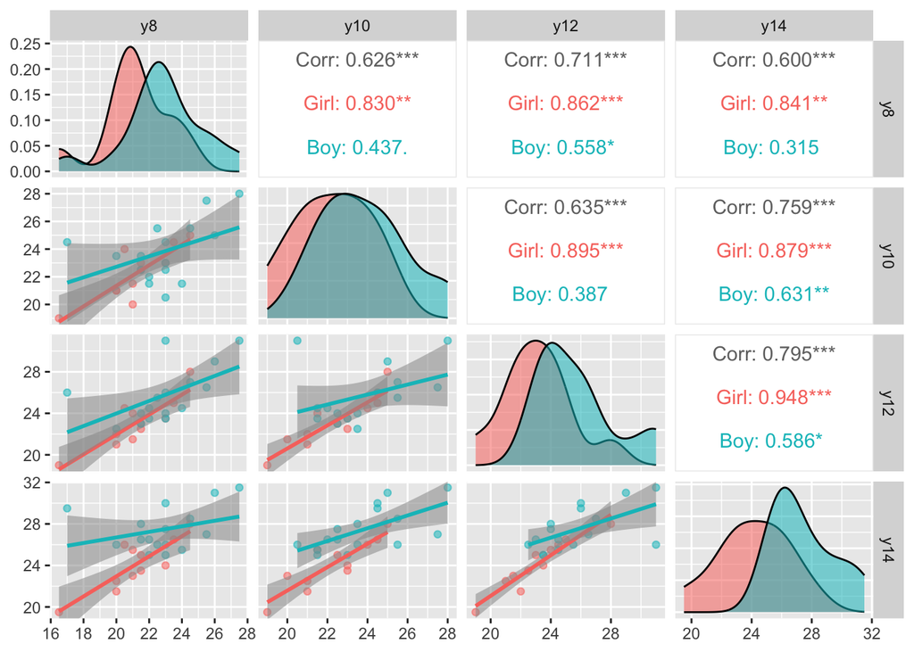

```r
ggpairs(dental, mapping = aes(colour = sex,alpha = 0.5), columns = 3:6,
        lower = list(continuous = "smooth"))
```

Digamos que queremos entender si el efecto varía con el tiempo. Podríamos evaluar gráficamente esto:

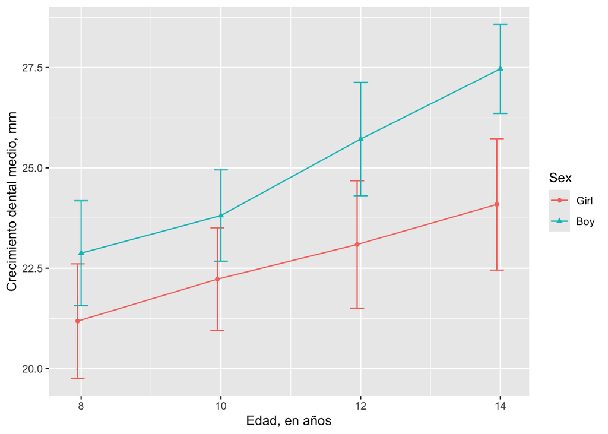

```r
group_by(dental_long, sex, age) |>
  summarise(mean = list(mean_ci(distance)), .groups = "drop") |>
  unnest_wider(mean) |>
  mutate(agex = age - .05 + .05*(sex == "Boy")) |>
  ggplot(aes(agex, y, col = sex, shape = sex)) +
  geom_point() +
  geom_errorbar(aes(ymin = ymin, ymax = ymax), width = 0.2) +
  geom_line() +
  labs(x = "Edad, en años", y = "Crecimiento dental medio, mm", shape = "Sex", col = "Sex")
```

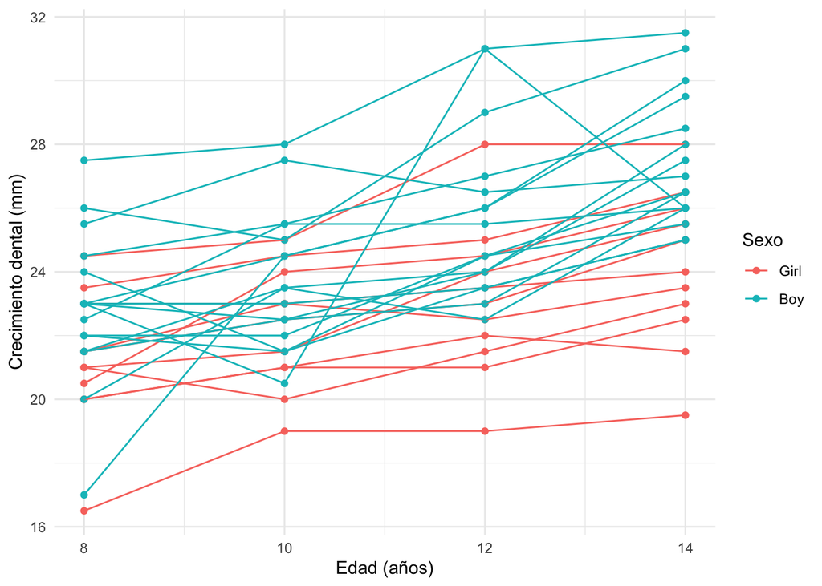

```r
ggplot(dental_long, aes(x = age, y = distance, color = sex)) +
  geom_point() +
  geom_line(aes(group = id)) +
  labs(x = "Edad (años)", y = "Crecimiento dental (mm)", color = "Sexo") +
  theme_minimal()
```

Para analizar los datos longitudinales, utilizamos modelos mixtos lineales, que permiten modelar tanto los efectos fijos (comunes a todos los individuos) como los efectos aleatorios (específicos de cada individuo).

## 8.1 Modelo inicial

Ajustamos un modelo que considera la edad como factor categórico (variables indicadoras) y un intercepto aleatorio para capturar la variabilidad entre individuos.

```r
# Ajustar el modelo mixto
modelo_edad <- lmer(distance ~ factor(age) + (1 | id), data = dental_long)

# Resumen del modelo
summary(modelo_edad)
```

```
## Linear mixed model fit by REML. t-tests use Satterthwaite's method [
## lmerModLmerTest]
## Formula: distance ~ factor(age) + (1 | id)
##    Data: dental_long
##
## REML criterion at convergence: 443.2
##
## Scaled residuals:
##     Min      1Q  Median      3Q     Max
## -3.7376 -0.5248  0.0153  0.4027  3.7212
##
## Random effects:
##  Groups   Name        Variance Std.Dev.
##  id       (Intercept) 4.465    2.113
##  Residual             2.078    1.442
## Number of obs: 108, groups:  id, 27
##
## Fixed effects:
##               Estimate Std. Error      df t value Pr(>|t|)
## (Intercept)    22.1852     0.4923 43.3911  45.066  < 2e-16 ***
## factor(age)10   0.9815     0.3924 78.0000   2.501   0.0145 *
## factor(age)12   2.4630     0.3924 78.0000   6.277 1.80e-08 ***
## factor(age)14   3.9074     0.3924 78.0000   9.958 1.52e-15 ***
## ---
## Signif. codes:  0 '***' 0.001 '**' 0.01 '*' 0.05 '.' 0.1 ' ' 1
##
## Correlation of Fixed Effects:
##             (Intr) fc()10 fc()12
## factor(g)10 -0.399
## factor(g)12 -0.399  0.500
## factor(g)14 -0.399  0.500  0.500
```

En este caso el intercepto captura la distancia media dental a los 8 años (valor de referencia). Esta es 22.18 mm. La diferencia entre las respuestas medias de los niños de 10 y 8 años es de 0.98 mm. La diferencia entre las respuestas medias de los niños de 12 y 8 años es de 2.46 mm. La diferencia entre las respuestas medias de los niños de 14 y 8 años es de 3.91 mm.

Esto indica que la distancia pituitaria-pterigomaxilar aumenta significativamente con la edad, lo que es consistente con el crecimiento observado durante este período.

Usamos un análisis de varianza para evaluar si la edad tiene un efecto significativo en el crecimiento dental.

```r
library(car)

Anova(modelo_edad)
```

```
## Analysis of Deviance Table (Type II Wald chisquare tests)
##
## Response: distance
##              Chisq Df Pr(>Chisq)
## factor(age) 114.12  3  < 2.2e-16 ***
## ---
## Signif. codes:  0 '***' 0.001 '**' 0.01 '*' 0.05 '.' 0.1 ' ' 1
```

El efecto de la edad es altamente significativo (p < 0.001), indicando que la edad influye en el crecimiento dental.

Calculamos las medias marginales estimadas para cada edad y sus intervalos de confianza.

```r
library(emmeans)

# Calcular las medias marginales
medias_edad <- emmeans(modelo_edad, ~ age)

# Mostrar los resultados
summary(medias_edad)
```

```
##  age emmean    SE   df lower.CL upper.CL
##    8   22.2 0.492 43.4     21.2     23.2
##   10   23.2 0.492 43.4     22.2     24.2
##   12   24.6 0.492 43.4     23.7     25.6
##   14   26.1 0.492 43.4     25.1     27.1
##
## Degrees-of-freedom method: kenward-roger
## Confidence level used: 0.95
```

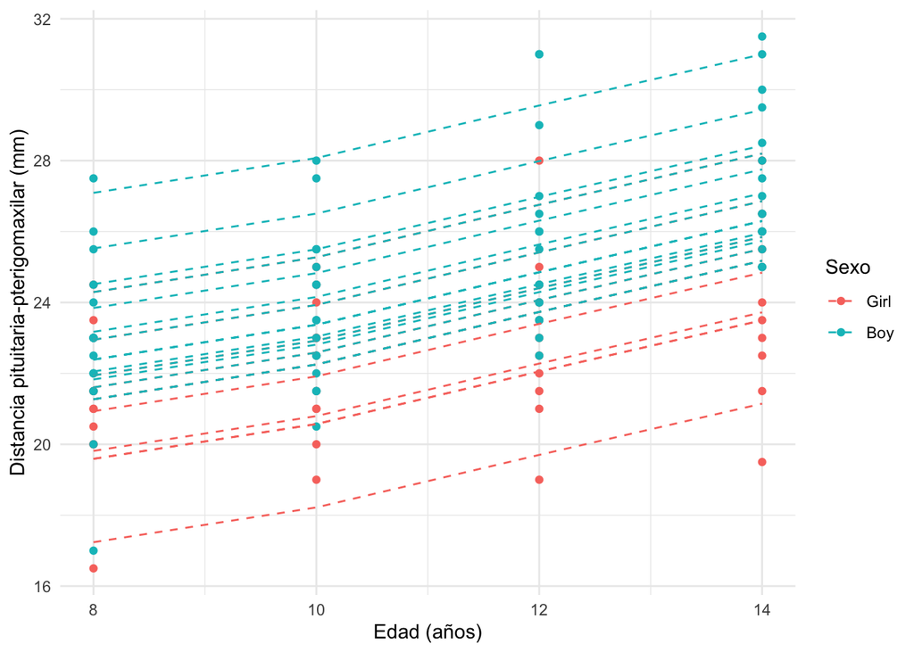

```r
# Generar predicciones del modelo ajustado
predicciones <- predict(modelo_edad)

# Visualizar la trayectoria estimada
ggplot(dental_long, aes(x = age, y = distance, color = sex)) +
  geom_point() +
  geom_line(aes(y = predicciones, group = id), linetype = "dashed") +
  labs(x = "Edad (años)", y = "Distancia pituitaria-pterigomaxilar (mm)", color = "Sexo") +
  theme_minimal()
```

Este gráfico muestra tanto los datos reales de distancia en función de la edad como las predicciones del modelo para cada niño, con líneas discontinuas que representan las trayectorias estimadas a lo largo del tiempo.

## 8.2 Modelo con variable de sexo

```r
# Ajustar el modelo con sexo y su interacción con la edad
modelo_sexo <- lmer(distance ~ factor(age) * sex + (1 | id), data = dental_long)

# Resumen del modelo
summary(modelo_sexo)
```

```
## Linear mixed model fit by REML. t-tests use Satterthwaite's method [
## lmerModLmerTest]
## Formula: distance ~ factor(age) * sex + (1 | id)
##    Data: dental_long
##
## REML criterion at convergence: 423.4
##
## Scaled residuals:
##     Min      1Q  Median      3Q     Max
## -3.7358 -0.4761  0.0469  0.4691  3.6613
##
## Random effects:
##  Groups   Name        Variance Std.Dev.
##  id       (Intercept) 3.285    1.813
##  Residual             1.975    1.405
## Number of obs: 108, groups:  id, 27
##
## Fixed effects:
##                      Estimate Std. Error      df t value Pr(>|t|)
## (Intercept)           21.1818     0.6915 46.0791  30.630  < 2e-16 ***
## factor(age)10          1.0455     0.5992 75.0000   1.745   0.0851 .
## factor(age)12          1.9091     0.5992 75.0000   3.186   0.0021 **
## factor(age)14          2.9091     0.5992 75.0000   4.855 6.41e-06 ***
## sexBoy                 1.6932     0.8983 46.0791   1.885   0.0658 .
## factor(age)10:sexBoy  -0.1080     0.7784 75.0000  -0.139   0.8901
## factor(age)12:sexBoy   0.9347     0.7784 75.0000   1.201   0.2337
## factor(age)14:sexBoy   1.6847     0.7784 75.0000   2.164   0.0336 *
## ---
## Signif. codes:  0 '***' 0.001 '**' 0.01 '*' 0.05 '.' 0.1 ' ' 1
##
## Correlation of Fixed Effects:
##             (Intr) fc()10 fc()12 fc()14 sexBoy f()10: f()12:
## factor(g)10 -0.433
## factor(g)12 -0.433  0.500
## factor(g)14 -0.433  0.500  0.500
## sexBoy      -0.770  0.334  0.334  0.334
## fctr(g)10:B  0.334 -0.770 -0.385 -0.385 -0.433
## fctr(g)12:B  0.334 -0.385 -0.770 -0.385 -0.433  0.500
## fctr(g)14:B  0.334 -0.385 -0.385 -0.770 -0.433  0.500  0.500
```

Interpretando salidas:

- La varianza del Intercepto Aleatorio (id) es 3.285 con una desviación estándar de 1.813. Existe variabilidad significativa entre los individuos en sus medidas iniciales de distancia dental.
- La varianza residual es 1.975 con una desviación estándar de 1.405. Esta captura variabilidad no explicadas por el modelo.
- El intercepto captura el ser una niña de 8 años como el punto de referencia: 21.1818mm.
- Coeficientes de factor(g)AA: El efecto de edad está dándonos el cambio en la distancia dental en comparación con la edad de referencia (8 años) para las niñas. Por ejemplo, las niñas de 10 años tienen, en promedio, una distancia dental 1.05 mm mayor que las niñas de 8 años, mientras que las de 14 años tienen, en promedio, una distancia dental 2.91 mm mayor que las niñas de 8 años.
- Coeficiente `sexBoy`: Los niños de 8 años tienen, en promedio, una distancia dental 1.69 mm mayor que las niñas de 8 años. Esta es una variable dummy.
- Los coeficientes de interacción indican cuánto cambia la diferencia entre niños y niñas en cada edad en comparación con la edad de referencia (8 años). Por ejemplo, a los 14 años, los niños tienen una distancia dental adicional de 1.68 mm en comparación con las niñas, más allá de la diferencia observada a los 8 años. Esa edad es la única que reporta distancias significativas a la referencia; al entrar más en la adolescencia las diferencias se tornan notables.

```r
Anova(modelo_sexo)
```

```
## Analysis of Deviance Table (Type II Wald chisquare tests)
##
## Response: distance
##                    Chisq Df Pr(>Chisq)
## factor(age)     120.0950  3  < 2.2e-16 ***
## sex               9.2921  1   0.002301 **
## factor(age):sex   7.0847  3   0.069247 .
## ---
## Signif. codes:  0 '***' 0.001 '**' 0.01 '*' 0.05 '.' 0.1 ' ' 1
```

El efecto de la edad es altamente significativo. Esto indica que existen diferencias significativas en la distancia dental media entre las diferentes edades (8, 10, 12 y 14 años), independientemente del sexo. También el sexo del paciente parece ser significativo. La interacción entre edad y sexo es marginalmente significativa (p < 0.10, pero > 0.05).

# 9 Series de tiempo: ejemplo de finanzas

Las series de tiempo son un conjunto de observaciones registradas en momentos sucesivos en el tiempo, ordenadas cronológicamente. El análisis de series de tiempo es fundamental en diversos campos como la economía, finanzas, meteorología, y ciencias sociales, ya que permite comprender y predecir comportamientos futuros basados en datos históricos.

En esta ñapita del taller, me enfoco en el análisis de series de tiempo financieras, específicamente en el estudio de los precios de las acciones. El objetivo es proporcionar una guía clara y práctica sobre modelos de series de tiempo utilizando R.

Las series de tiempo financieras, como los precios de las acciones o los tipos de cambio, son intrínsecamente volátiles y están influenciadas por múltiples factores económicos y políticos. El análisis de estas series permite a los inversores y analistas comprender las tendencias del mercado, evaluar riesgos, anticiparse a estas y tomar decisiones informadas.

Para este análisis, utilizaremos datos históricos del precio de cierre ajustado de las acciones de Apple Inc. (AAPL). Usaremos el paquete quantmod para descargar los datos directamente desde Yahoo Finance.

```r
# Instalar paquetes si no están instalados
#install.packages("quantmod")
#install.packages("forecast")
#install.packages("tseries")
#install.packages("ggplot2")
#install.packages("quantmod", repos = "https://cloud.r-project.org/")

# Cargar los paquetes
library(quantmod)
library(forecast)
library(tseries)
library(ggplot2)
```

```r
# Establecer el rango de fechas
fecha_inicio <- as.Date("2019-01-01")
fecha_fin <- as.Date(Sys.Date())

# Descargar los datos de AAPL
getSymbols("AAPL", src = "yahoo", from = fecha_inicio, to = fecha_fin)
```

```
## [1] "AAPL"
```

```r
# Ver las primeras filas
head(AAPL)
```

```
##            AAPL.Open AAPL.High AAPL.Low AAPL.Close AAPL.Volume AAPL.Adjusted
## 2019-01-02   38.7225   39.7125  38.5575    39.4800   148158800      37.66718
## 2019-01-03   35.9950   36.4300  35.5000    35.5475   365248800      33.91526
## 2019-01-04   36.1325   37.1375  35.9500    37.0650   234428400      35.36307
## 2019-01-07   37.1750   37.2075  36.4750    36.9825   219111200      35.28436
## 2019-01-08   37.3900   37.9550  37.1300    37.6875   164101200      35.95699
## 2019-01-09   37.8225   38.6325  37.4075    38.3275   180396400      36.56760
```

Extraemos la columna de precios de cierre ajustados y creamos un objeto de serie de tiempo.

```r
# Extraer el precio de cierre ajustado
precio_cierre <- AAPL[, "AAPL.Adjusted"]

# Convertir a serie de tiempo
serie_tiempo <- ts(precio_cierre, frequency = 252)  # 252 días hábiles en un año
```

Antes de ajustar cualquier modelo, es importante entender las características de la serie de tiempo.

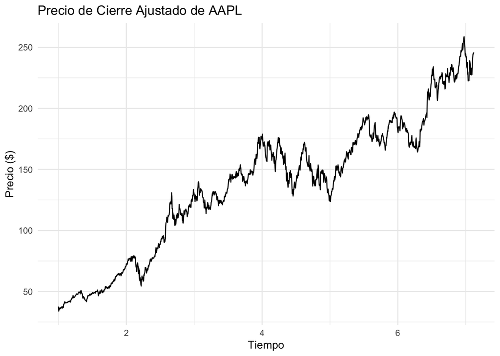

```r
# Graficar la serie de tiempo
autoplot(serie_tiempo) +
  labs(title = "Precio de Cierre Ajustado de AAPL",
       x = "Tiempo",
       y = "Precio ($)") +
  theme_minimal()
```

El gráfico muestra la evolución del precio de AAPL desde 2019 hasta la fecha actual. Observamos tendencias ascendentes y periodos de volatilidad, especialmente durante eventos económicos significativos como la pandemia de COVID-19 y la subsiguiente alza en valuaciones financieras.

Descomponemos la serie para analizar sus componentes: tendencia, estacionalidad y residuales.

```r
# Verificar la estructura de 'serie_tiempo'
str(serie_tiempo)
```

```
##  Time-Series [1:1543, 1] from 1 to 7.12: 37.7 33.9 35.4 35.3 36 ...
##  - attr(*, "index")= num [1:1543] 1.55e+09 1.55e+09 1.55e+09 1.55e+09 1.55e+09 ...
##   ..- attr(*, "tzone")= chr "UTC"
##   ..- attr(*, "tclass")= chr "Date"
##  - attr(*, "src")= chr "yahoo"
##  - attr(*, "updated")= POSIXct[1:1], format: "2025-02-21 11:19:33"
##  - attr(*, "dimnames")=List of 2
##   ..$ : NULL
##   ..$ : chr "AAPL.Adjusted"
```

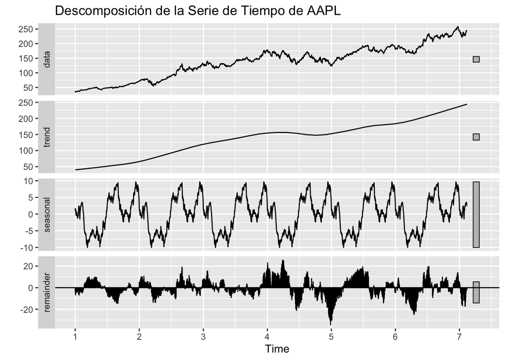

```r
# Convertir a vector numérico
precio_cierre_vector <- as.numeric(precio_cierre)

# Crear la serie de tiempo
serie_tiempo <- ts(precio_cierre_vector, frequency = 252)

# Descomposición utilizando STL (Seasonal and Trend decomposition using Loess)
descomposición <- stl(serie_tiempo, s.window = "periodic")

# Graficar la descomposición
autoplot(descomposición) +
  labs(title = "Descomposición de la Serie de Tiempo de AAPL")
```

- Tendencia: Muestra el movimiento a largo plazo del precio.
- Estacionalidad: En series financieras diarias, la estacionalidad puede no ser pronunciada, pero pueden existir patrones semanales o mensuales.
- Residuales: Parte de la serie no explicada por la tendencia ni la estacionalidad.

La estacionariedad es una propiedad clave en el análisis de series de tiempo. Una serie estacionaria tiene estadísticas (media, varianza) constantes en el tiempo. Realizamos la prueba Dickey-Fuller Aumentada (ADF) para verificar si la serie es estacionaria.

```r
# Prueba ADF
adf.test(serie_tiempo, alternative = "stationary")
```

```
##
##  Augmented Dickey-Fuller Test
##
## data:  serie_tiempo
## Dickey-Fuller = -2.8935, Lag order = 11, p-value = 0.2001
## alternative hypothesis: stationary
```

El p-valor es alto (mayor que 0.05), lo que indica que no podemos rechazar la hipótesis nula de que la serie tiene una raíz unitaria (no estacionaria). Concluimos que la serie no es estacionaria.

Para lograr estacionariedad, transformamos los precios en rendimientos logarítmicos.

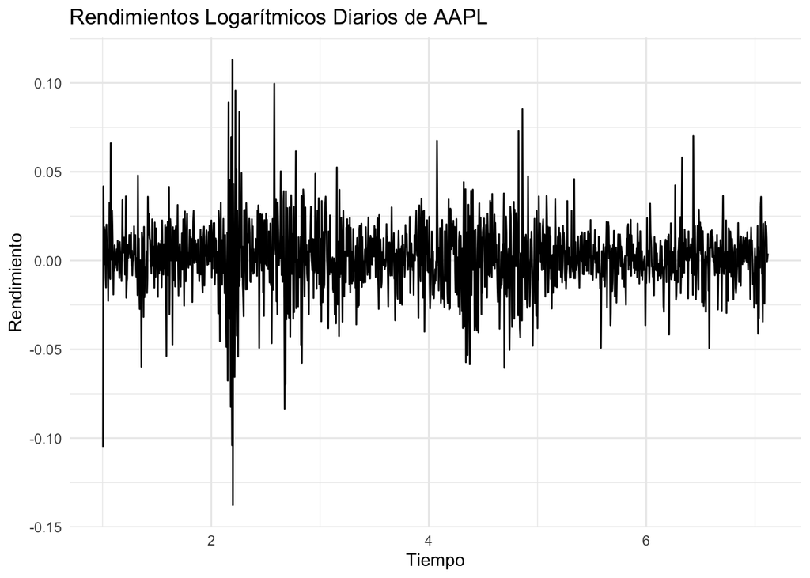

```r
# Calcular los rendimientos logarítmicos
rendimientos <- diff(log(serie_tiempo))

# Graficar los rendimientos
autoplot(rendimientos) +
  labs(title = "Rendimientos Logarítmicos Diarios de AAPL",
       x = "Tiempo",
       y = "Rendimiento") +
  theme_minimal()
```

Verificamos nuevamente la serie transformada con ADF.

```r
# Prueba ADF en los rendimientos
adf.test(rendimientos, alternative = "stationary")
```

```
##
##  Augmented Dickey-Fuller Test
##
## data:  rendimientos
## Dickey-Fuller = -10.956, Lag order = 11, p-value = 0.01
## alternative hypothesis: stationary
```

El p-valor es bajo (0.01), lo que indica que podemos rechazar la hipótesis nula.

El modelo ARIMA (Autoregressive Integrated Moving Average) es ampliamente utilizado para modelar series de tiempo estacionarias. Analizamos las funciones de autocorrelación (ACF) y autocorrelación parcial (PACF) para identificar los órdenes del modelo.

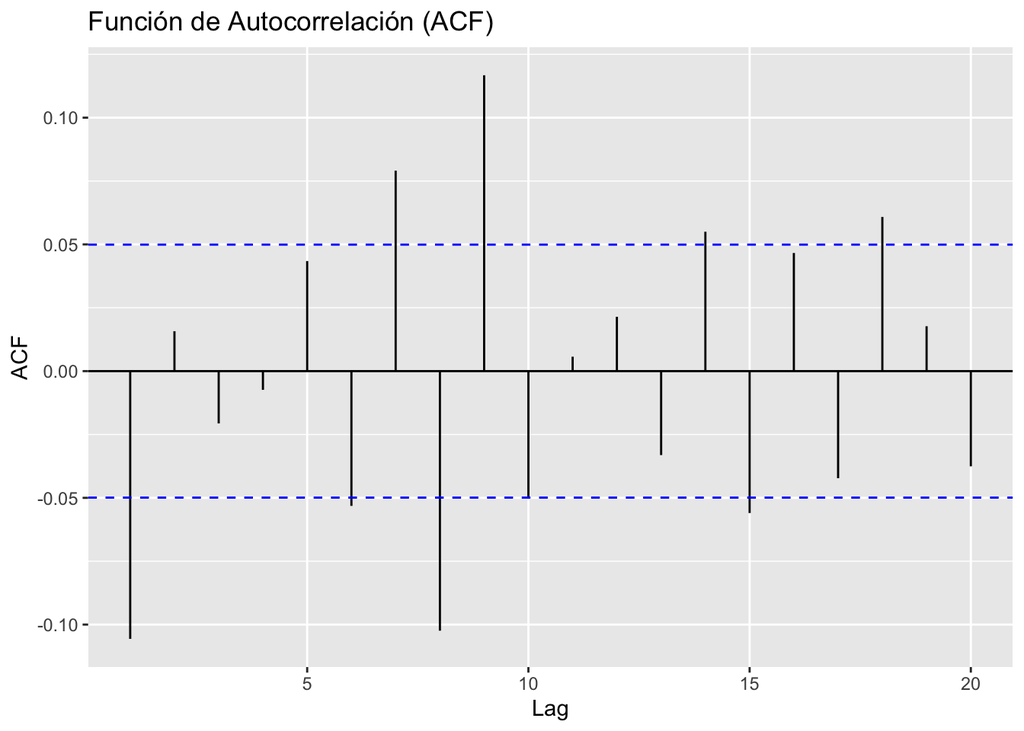

```r
# Graficar ACF y PACF
ggAcf(rendimientos, lag.max = 20) + ggtitle("Función de Autocorrelación (ACF)")
```

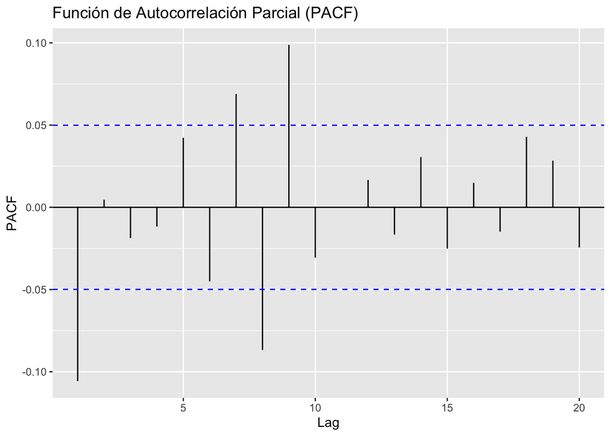

```r
ggPacf(rendimientos, lag.max = 20) + ggtitle("Función de Autocorrelación Parcial (PACF)")
```

Las gráficas nos ayudan a identificar posibles valores de p y q para el modelo ARIMA(p, d, q). En los rendimientos financieros, a menudo se observa poca autocorrelación significativa. También podríamos hacer que el algoritmo seleccione los valores para el modelo. Para esto utilizamos la función `auto.arima()`, y seleccionará estos usando criterios de información (AICc).

```r
# Selección automática del modelo ARIMA
modelo_arima <- auto.arima(rendimientos, seasonal = FALSE)

# Resumen del modelo
summary(modelo_arima)
```

```
## Series: rendimientos
## ARIMA(1,0,0) with non-zero mean
##
## Coefficients:
##           ar1    mean
##       -0.1077  0.0012
## s.e.   0.0256  0.0004
##
## sigma^2 = 0.0003724:  log likelihood = 3900.4
## AIC=-7794.81   AICc=-7794.79   BIC=-7778.79
##
## Training set error measures:
##                         ME       RMSE        MAE MPE MAPE     MASE       ACF1
## Training set -6.264498e-06 0.01928577 0.01360626 NaN  Inf 0.629489 0.00255728
```

El modelo seleccionado es un ARIMA(1,0,0), es decir, un modelo ARMA con un término autorregresivo pero sin media móvil, realmente, un modelo AR.

Verificamos si el modelo ajustado cumple con los supuestos necesarios.

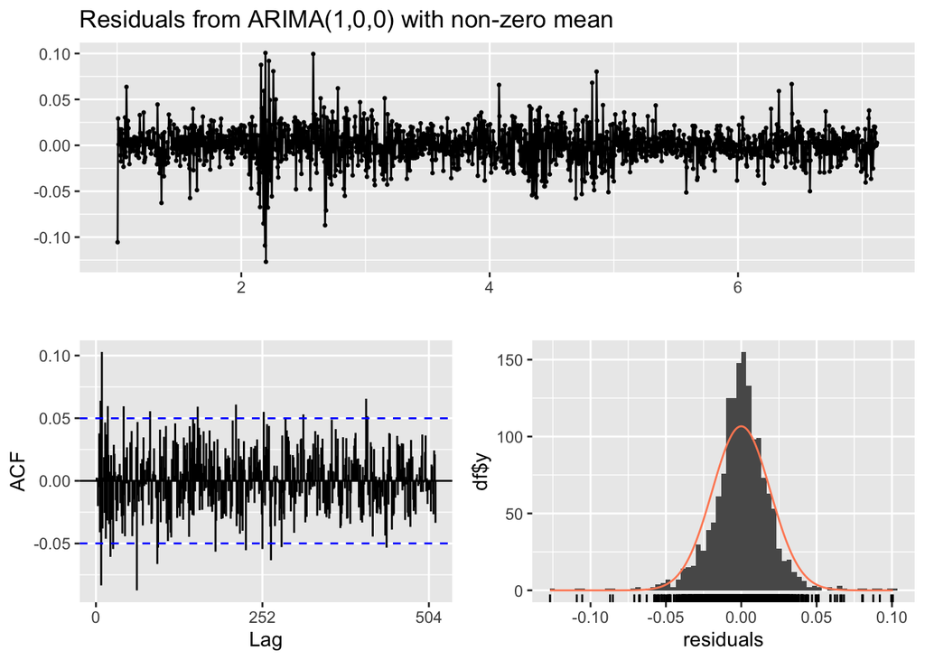

```
##
##  Ljung-Box test
##
## data:  Residuals from ARIMA(1,0,0) with non-zero mean
## Q* = 399.91, df = 307, p-value = 0.0002774
##
## Model df: 1.   Total lags used: 308
```

```r
# Graficar los residuos
checkresiduals(modelo_arima)
```

Podríamos verificar la heteroscedasticidad. En series financieras, es común que exista esta estructura en los datos.

```r
# Prueba de Arch
library(FinTS)
ArchTest(resid(modelo_arima))
```

```
##
##  ARCH LM-test; Null hypothesis: no ARCH effects
##
## data:  resid(modelo_arima)
## Chi-squared = 279.59, df = 12, p-value < 2.2e-16
```

Para capturar la heterocedasticidad, utilizamos modelos GARCH (Generalized Autoregressive Conditional Heteroskedasticity). Utilizamos el paquete `rugarch` para ajustar un modelo GARCH.

```r
# Instalar y cargar el paquete rugarch
#install.packages("rugarch")
library(rugarch)
# Especificar el modelo ARIMA(1,0,0)-GARCH(1,1)
especificacion <- ugarchspec(mean.model = list(armaOrder = c(1,0)),
                             variance.model = list(model = "sGARCH", garchOrder = c(1,1)),
                             distribution.model = "norm")

# Ajustar el modelo
modelo_garch <- ugarchfit(spec = especificacion, data = rendimientos)

# Resumen del modelo
show(modelo_garch)
```

```
##
## *---------------------------------*
## *          GARCH Model Fit        *
## *---------------------------------*
##
## Conditional Variance Dynamics
## -----------------------------------
## GARCH Model  : sGARCH(1,1)
## Mean Model   : ARFIMA(1,0,0)
## Distribution : norm
##
## Optimal Parameters
## ------------------------------------
##         Estimate  Std. Error  t value Pr(>|t|)
## mu      0.001821    0.000400   4.5498 0.000005
## ar1    -0.016881    0.027718  -0.6090 0.542523
## omega   0.000014    0.000002   9.1626 0.000000
## alpha1  0.095643    0.007511  12.7342 0.000000
## beta1   0.862210    0.012626  68.2873 0.000000
##
## Robust Standard Errors:
##         Estimate  Std. Error  t value Pr(>|t|)
## mu      0.001821    0.000444   4.1046 0.000041
## ar1    -0.016881    0.026184  -0.6447 0.519122
## omega   0.000014    0.000003   4.5296 0.000006
## alpha1  0.095643    0.012300   7.7758 0.000000
## beta1   0.862210    0.017499  49.2729 0.000000
##
## LogLikelihood : 4052.176
##
## Information Criteria
## ------------------------------------
##
## Akaike       -5.2493
## Bayes        -5.2319
## Shibata      -5.2493
## Hannan-Quinn -5.2428
##
## Weighted Ljung-Box Test on Standardized Residuals
## ------------------------------------
```

[output cut: 40 more lines]

```
## Negative Sign Bias  0.4823 0.6297
## Positive Sign Bias  0.3711 0.7107
## Joint Effect        3.4361 0.3291
##
##
## Adjusted Pearson Goodness-of-Fit Test:
## ------------------------------------
##   group statistic p-value(g-1)
## 1    20     53.82    3.513e-05
## 2    30     55.43    2.205e-03
## 3    40     84.87    2.997e-05
## 4    50     86.79    7.086e-04
##
##
## Elapsed time : 0.06296301
```

Las pruebas diagnósticas indican que no aparentan haber ni autocorrelación significativa en los residuos ni en los residuos al cuadrado, así como tampoco aparentan haber sesgos significativos en los residuos (signos). El modelo GARCH parece haber capturado adecuadamente la heteroscedasticidad. Los parámetros podrían ser algo inestables (verificar Nyblom)

```
##
## please wait...calculating quantiles...
```

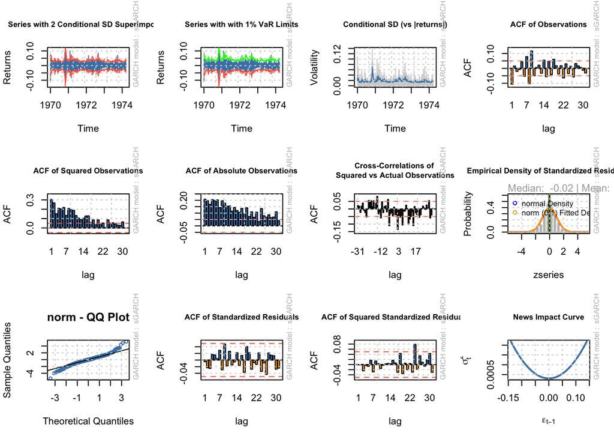

```r
# Graficar los residuos estandarizados
plot(modelo_garch, which = "all")
```

Podría considerar un modelo más sencillo sin AR(1), y con colas más amplias en distribución t.

```r
# Especificación de un modelo GARCH(1,1) sin término AR(1)
especificacion_simple <- ugarchspec(mean.model = list(armaOrder = c(0,0)),
                                    variance.model = list(model = "sGARCH", garchOrder = c(1,1)),
                                    distribution.model = "norm")

modelo_garch_simple <- ugarchfit(spec = especificacion_simple, data = rendimientos)

# Modelo GARCH con distribución t de Student
especificacion_t <- ugarchspec(mean.model = list(armaOrder = c(0,0)),
                               variance.model = list(model = "sGARCH", garchOrder = c(1,1)),
                               distribution.model = "std")

modelo_garch_t <- ugarchfit(spec = especificacion_t, data = rendimientos)
modelo_garch_t
```

```
##
## *---------------------------------*
## *          GARCH Model Fit        *
## *---------------------------------*
##
## Conditional Variance Dynamics
## -----------------------------------
## GARCH Model  : sGARCH(1,1)
## Mean Model   : ARFIMA(0,0,0)
## Distribution : std
##
## Optimal Parameters
## ------------------------------------
##         Estimate  Std. Error  t value Pr(>|t|)
## mu      0.001716    0.000376   4.5639    5e-06
## omega   0.000010    0.000002   4.4600    8e-06
## alpha1  0.086017    0.000829 103.7993    0e+00
## beta1   0.887120    0.013008  68.2000    0e+00
## shape   5.326705    0.615867   8.6491    0e+00
##
## Robust Standard Errors:
##         Estimate  Std. Error  t value Pr(>|t|)
## mu      0.001716    0.000397   4.3209 0.000016
## omega   0.000010    0.000004   2.6788 0.007389
## alpha1  0.086017    0.013164   6.5342 0.000000
## beta1   0.887120    0.014534  61.0362 0.000000
## shape   5.326705    0.794058   6.7082 0.000000
##
## LogLikelihood : 4105.281
##
## Information Criteria
## ------------------------------------
##
## Akaike       -5.3181
## Bayes        -5.3008
## Shibata      -5.3182
## Hannan-Quinn -5.3117
##
## Weighted Ljung-Box Test on Standardized Residuals
## ------------------------------------
```

[output cut: 40 more lines]

```
## Negative Sign Bias  0.6691 0.5035
## Positive Sign Bias  0.3585 0.7200
## Joint Effect        2.9259 0.4032
##
##
## Adjusted Pearson Goodness-of-Fit Test:
## ------------------------------------
##   group statistic p-value(g-1)
## 1    20     20.33       0.3747
## 2    30     23.06       0.7739
## 3    40     31.59       0.7944
## 4    50     38.22       0.8670
##
##
## Elapsed time : 0.05875206
```

Finalmente, quiero visualizar usando el ARIMA(1,0,0) el rendimiento futuro de AAPL por 15 días.

Uso para esto la función `forecast()`: Esta función del paquete forecast genera pronósticos basados en el modelo ARIMA ajustado (`modelo_arima`). Con `h=15` indico que quiero saber los próximos 15 periodos (días). Graficamos ese pronóstico con `autoplot`, y algo de personalización.

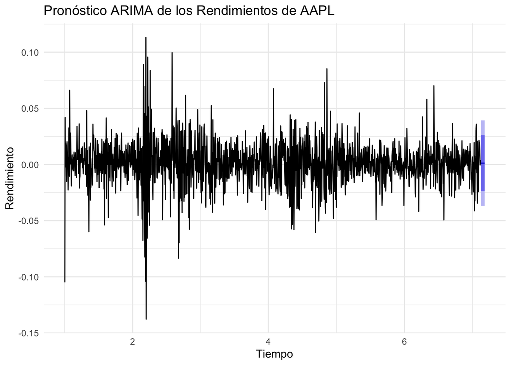

```r
# Pronóstico de los próximos 15 días
pronostico_arima <- forecast(modelo_arima, h = 15)

# Graficar el pronóstico
autoplot(pronostico_arima) +
  labs(title = "Pronóstico ARIMA de los Rendimientos de AAPL",
       x = "Tiempo",
       y = "Rendimiento") +
  theme_minimal()
```

```r
# Pronóstico de la volatilidad futura
pronostico_garch <- ugarchforecast(modelo_garch, n.ahead = 10)

# Extraer la volatilidad pronosticada
volatilidad_pronosticada <- sigma(pronostico_garch)

# Mostrar los resultados
volatilidad_pronosticada
```

```
##      1974-03-23
## T+1  0.01544669
## T+2  0.01557927
## T+3  0.01570522
## T+4  0.01582492
## T+5  0.01593874
## T+6  0.01604700
## T+7  0.01615001
## T+8  0.01624808
## T+9  0.01634145
## T+10 0.01643040
```

- Los pronósticos nos ayudan a entender las posibles tendencias futuras en los rendimientos y la volatilidad.

Conclusiones

- Análisis Exploratorio: Identificamos que los precios de las acciones no son estacionarios, pero los rendimientos logarítmicos sí lo son.
- Modelado ARIMA: Ajustamos un modelo ARIMA para capturar la dinámica en los rendimientos.
- Volatilidad y GARCH: Detectamos heterocedasticidad y utilizamos un modelo GARCH para modelar la volatilidad condicional.
- Pronósticos: Generamos pronósticos de rendimientos y volatilidad.

Es importante tener en cuenta que los mercados financieros son influenciados por muchos factores impredecibles, y ningún modelo puede capturar completamente esa complejidad. Por lo tanto, los pronósticos deben interpretarse con cautela y complementarse con análisis cualitativos y contextualizados.

Recomiendo aplicar estos métodos a diferentes activos financieros o índices para fortalecer la comprensión. Además de R, existen otras herramientas como Python y EViews que también son útiles para el análisis de series de tiempo. EViews está en declive según tengo entendido, pero sigue siendo utilizado en varios espacios.

# 10 Qué aprendimos en este taller

Aprendimos la existencia de varios modelos, maneras de representar gráficamente sus resultados, y evaluar su utilidad. He añadido elementos que aumentan la descripción de pedazos del taller, y que buscan corregir el orden en el que se trabajaron ejemplos.

Nos veremos próximamente (fecha por determinar en el taller) con un nuevo tema: análisis de redes.